# metadid Simulation Validation Report

Author

metadid-sims pipeline

Published

October 29, 2026

```r
library(targets)
library(dplyr)
library(ggplot2)
library(knitr)
library(kableExtra)

tar_source("R/scenarios.R")
tar_source("R/plots.R")

all_agg <- tar_read(all_agg)
all_rep <- tar_read(all_rep)
scenario_lookup_tbl <- scenario_lookup()
```

## Executive Summary

```r
# Two kinds of scenario need two kinds of test.
#
# VALIDATION categories (A-I, X) ask whether the model is calibrated, so
# "coverage below 80%" is a meaningful failure.
#
# FIGURE SWEEPS (J-P) exist to locate where the model breaks so the paper can
# plot it. A sweep that never lost coverage would be a badly designed sweep, so
# a coverage floor scores their success as failure. They are excluded from the
# defect count here and remain in the full results table below.
#
# Category X is additionally COMPARATIVE: several of its arms exist to be shown
# failing, so per-arm coverage tests a claim those scenarios never make. What
# they do claim is an ordering, checked separately by check_contrasts().
mean_agg <- all_agg |>
  filter(parameter == "treatment_effect_mean") |>
  mutate(category = substr(scenario_id, 1L, 1L))

sweeps <- mean_agg |> filter(category %in% FIGURE_SWEEP_CATEGORIES)

flagged <- bind_rows(
  mean_agg |> filter(category %in% VALIDATION_CATEGORIES,
                     !category %in% "X",
                     empirical_coverage < 0.80) |>
    mutate(issue = "coverage < 80%"),
  mean_agg |> filter(category %in% VALIDATION_CATEGORIES,
                     pct_rhat_bad > 0.10) |>
    mutate(issue = ">10% of fits Rhat > 1.05")
) |>
  tag_expectations() |>
  left_join(scenario_lookup(), by = "scenario_id")

genuine   <- flagged |> filter(!expected)
expected  <- flagged |> filter(expected)
contrasts <- check_contrasts(all_agg)
open_issues <- known_open_issues()
resolved    <- resolved_issues()
```

**6 genuine calibration issue(s)** on the treatment-effect mean need attention (below). A further 20 flagged result(s) are expected by design.

**Category X contrasts:** 8 of 8 directional claims hold. Every comparative scenario ordered its arms as predicted.

### Known open issues

**None.** Issues that were open and have since been explained are listed below, with their cause – a report that simply stopped mentioning one would leave you unable to tell a fix from an oversight.

```r
open_issues |>
  select(Issue = id, Affects = affects, Detail = summary) |>
  kable()
```

```r
resolved |>
  select(Resolved = id, Affected = affects, Cause = cause, Fix = fix) |>
  kable(caption = "Previously open issues, with the cause that was found")
```

Previously open issues, with the cause that was found

| Resolved | Affected | Cause | Fix |
| --- | --- | --- | --- |
| post-only-residual-bias | X1-X9, X13-X18 (any composition dominated by post-only studies) | A defect in THIS repo, not in metadid. The post-only branch of simulate_imbalance_grid never drew `betas`, so a post-only study’s arms sat at the latent pre-treatment level: control at b rather than b… | The trend is now applied to post-only arms. Three invariants are tested in test-simulate-imbalance.R: the trend must appear in a post-only study’s arm levels, must cancel from its arm contrast, and a … |

### Category X: do the comparative scenarios order their arms as claimed?

Each row is a claim a scenario makes – that the arm named `better` gets closer to the truth than the arm named `worse`. This replaces per-arm coverage flags for category X, because several of its arms exist to be shown failing.

```r
contrasts |>
  mutate(across(c(better_rmse, worse_rmse), \(x) round(x, 4)),
         holds = ifelse(holds, "yes", "NO")) |>
  select(Scenario = scenario_id, Claim = claim,
         Better = better, `RMSE` = better_rmse,
         Worse = worse, `RMSE ` = worse_rmse, Holds = holds) |>
  kable()
```

| Scenario | Claim | Better | RMSE | Worse | RMSE | Holds |
| --- | --- | --- | --- | --- | --- | --- |
| X1 | zero-mean gamma beats a shared population when the RCTs really are randomised | zero_mean | 0.0183 | shared | 0.0358 | yes |
| X2 | as X1, at a larger DiD imbalance | zero_mean | 0.0252 | shared | 0.0562 | yes |
| X3 | as X1, at a larger DiD imbalance still | zero_mean | 0.0181 | shared | 0.0419 | yes |
| X19 | pinning mu_gamma avoids the delta_rct ridge | mu_gamma_zero | 0.0264 | mu_gamma_est | 0.0267 | yes |
| B6 | zero-mean gamma beats a shared population when DiD imbalance exceeds post-only imbalance (n = 25) | zero_mean | 0.0268 | full | 0.0341 | yes |
| X25 | PP scale mismatch attenuates the normalised estimate (gamma = 0.04) | raw | 0.0089 | normalised | 0.0312 | yes |
| X26 | PP scale mismatch attenuates the normalised estimate (gamma = 0.08) | raw | 0.0084 | normalised | 0.0374 | yes |
| X27 | PP scale mismatch attenuates the normalised estimate (gamma = 0.12) | raw | 0.0076 | normalised | 0.0424 | yes |

### Genuine issues

```r
kable(
  genuine |>
    select(scenario_id, description, model_label, issue,
           empirical_coverage, mean_bias, rmse, pct_rhat_bad),
  digits = 3,
  caption = "Genuine issues on treatment_effect_mean (coverage < 80% or convergence)"
)
```

Genuine issues on treatment_effect_mean (coverage < 80% or convergence)

| scenario_id | description | model_label | issue | empirical_coverage | mean_bias | rmse | pct_rhat_bad |
| --- | --- | --- | --- | --- | --- | --- | --- |
| A12 | Individual vs summary consistency: same data, fit both ways, 20 studies | individual | coverage < 80% | 0.733 | 0.004 | 0.025 | 0.000 |
| A12 | Individual vs summary consistency: same data, fit both ways, 20 studies | summary | coverage < 80% | 0.733 | 0.004 | 0.026 | 0.000 |
| B6 | DiD imbalance > post-only imbalance: pooled vs zero-mean vs naive, 15 DiD + 15 RCT | zero_mean | coverage < 80% | 0.720 | 0.019 | 0.027 | 0.000 |
| I7 | Multiplicative covariate, individual-level data, 20 DiD | modelled | coverage < 80% | 0.733 | -0.011 | 0.034 | 0.000 |
| X5 | Direction: DiD gamma +/-0.08 (sign-flipped), RCTs truly randomised | shared | >10% of fits Rhat > 1.05 | 0.867 | -0.006 | 0.027 | 0.133 |
| X6 | Direction: DiD gamma +/-0.12 (sign-flipped), RCTs truly randomised | shared | >10% of fits Rhat > 1.05 | 0.800 | -0.002 | 0.024 | 0.200 |

### Expected by design (not defects)

These deviations are intended — misspecification demonstrations, boundary/degenerate setups, or deliberate normalisation stress tests — and are listed for completeness.

```r
kable(
  expected |>
    select(scenario_id, description, model_label, issue,
           empirical_coverage, mean_bias, reason),
  digits = 3,
  caption = "Expected-by-design deviations on treatment_effect_mean"
)
```

Expected-by-design deviations on treatment_effect_mean

| scenario_id | description | model_label | issue | empirical_coverage | mean_bias | reason |
| --- | --- | --- | --- | --- | --- | --- |
| B1 | Naive vs full: PP-heavy, large trend (full should win) | naive | coverage < 80% | 0.00 | -0.189 | Naive arm zeros a large PP time trend — misspecified by design (‘full should win’) |
| B3 | Naive wins: DiD trend = 0, PP trend = -0.10 (pooled borrows wrong trend) | full | coverage < 80% | 0.28 | -0.084 | Demonstrates pooled-trend failure when trends differ by design (‘naive wins’) |
| B3 | Naive wins: DiD trend = 0, PP trend = -0.10 (pooled borrows wrong trend) | naive | coverage < 80% | 0.00 | -0.111 | Naive comparison arm — misspecified by design |
| B5 | Unrandomised post-only imbalance (only in this design): pooled vs zero-mean vs naive, 10 DiD + 10 RCT | full | coverage < 80% | 0.16 | 0.064 | RCT baseline imbalance not per-study identifiable; full model relies on hierarchical borrowing from few DiD — under-coverage expected |
| B5 | Unrandomised post-only imbalance (only in this design): pooled vs zero-mean vs naive, 10 DiD + 10 RCT | naive | coverage < 80% | 0.08 | 0.072 | Naive arm ignores RCT baseline imbalance — biased by design |
| B5 | Unrandomised post-only imbalance (only in this design): pooled vs zero-mean vs naive, 10 DiD + 10 RCT | zero_mean | coverage < 80% | 0.04 | 0.070 | Same identification limit as the full arm: post-only imbalance is not per-study identifiable, and pinning mu_gamma does not create information that is not there. All three arms under-cover comparably … |
| B6 | DiD imbalance > post-only imbalance: pooled vs zero-mean vs naive, 15 DiD + 15 RCT | full | coverage < 80% | 0.72 | -0.027 | Shared baseline-difference hierarchy is dominated by the larger DiD imbalance and mis-applies it to RCT — bias expected by design (see category X, which isolates this) |
| B6 | DiD imbalance > post-only imbalance: pooled vs zero-mean vs naive, 15 DiD + 15 RCT | naive | coverage < 80% | 0.28 | 0.033 | Naive arm ignores baseline imbalance — biased by design |
| C6 | Asymmetric contamination: outliers all biased in same direction | normal | coverage < 80% | 0.60 | 0.055 | One-directional contamination shifts the mean even under robust heterogeneity — both arms biased by design |
| C6 | Asymmetric contamination: outliers all biased in same direction | robust | coverage < 80% | 0.72 | 0.045 | One-directional contamination shifts the mean even under robust heterogeneity — both arms biased by design |
| D4 | Effect heterogeneity correlated with sample size | default | coverage < 80% | 0.00 | 0.130 | Effect correlated with sample size — informative-sampling misspecification demo |
| D5 | Baseline imbalance in RCT with baseline_imbalance=‘fixed_zero’ | default | coverage < 80% | 0.04 | 0.073 | baseline_imbalance = fixed_zero on real imbalance — misspecification demo |
| H1 | Skewed trends: beta_i ~ -LogNormal (mean = -0.04, log-SD = 1), 15 DiD + 15 PP | naive | coverage < 80% | 0.20 | -0.055 | Naive arm — misspecified by design |
| H2 | Bimodal trends: 50/50 mixture N(-0.10, 0.01) + N(-0.01, 0.01), 15 DiD + 15 PP | naive | coverage < 80% | 0.20 | -0.058 | Naive arm — misspecified by design |
| H4 | Trend-size confounding: DiD n ~ U(30,70), PP n ~ U(150,250), 15 DiD + 15 PP | full_normal | coverage < 80% | 0.44 | 0.043 | Trend confounded with study size and design (DiD small, PP large); the pooled-trend model cannot separate them — all arms biased by design |
| H4 | Trend-size confounding: DiD n ~ U(30,70), PP n ~ U(150,250), 15 DiD + 15 PP | full_robust | coverage < 80% | 0.36 | 0.043 | Trend confounded with study size and design (DiD small, PP large); the pooled-trend model cannot separate them — all arms biased by design |
| I5 | Omit-multiplier misspecification: truth has binary multiplier, fit with vs without (× modelled/raw) | without_modelled | coverage < 80% | 0.04 | 0.066 | Multiplier omitted when truth has it — misspecification demo |
| I5 | Omit-multiplier misspecification: truth has binary multiplier, fit with vs without (× modelled/raw) | without_raw | coverage < 80% | 0.00 | 0.029 | Multiplier omitted when truth has it — misspecification demo |
| E5 | Single study per design: 1 DiD + 1 RCT + 1 PP | default | >10% of fits Rhat > 1.05 | 1.00 | 0.077 | One study per design — between-study heterogeneity is unidentified by construction |
| G9 | Jensen’s test: n_control = 5000, high within-study precision (100 DiD) | default | >10% of fits Rhat > 1.05 | 0.88 | 0.002 | Jensen’s test: high within-study precision deliberately stresses the normalisation nonlinearity |

## Paper Figure

The publication figures are **not** rendered in this report. Figure 1 and Figure 2 are built by the `paper-figure` workflow, which simulates the figure-only categories (K, M, Q, R, S, T) itself and publishes `figure1`/`figure2` (PNG and PDF) plus `figure_panels.csv`, `illustration_draws.csv` and `paired_rmse_MT.csv` as run artifacts.

Those categories are deliberately excluded from this nightly pipeline: they are generated programmatically, so the scenario matrix in `sims.yaml` cannot see them, and pulling them into `all_agg` would make this report’s job re-simulate every one of them serially on a single runner.

The nightly sweep aggregates are still exported as `output/figure_panels.csv` (target `figure_data_csv`), tagged by scenario category.

## A. Calibration Studies

These scenarios test the model’s core calibration properties — coverage, bias, and RMSE — under a range of study counts, design mixes, and parameterisations. All use the full `meta_did` model unless noted. The baseline scenario (A1) uses 20 DiD studies with default parameters; subsequent scenarios probe how performance changes with sample size (A2–A4), mixed designs (A5–A6), covariates (A7), correlated effects (A8), unnormalised fitting (A9–A10), individual-level data (A11–A12), rho estimation strategies (A13), and sign/direction variants (A14–A18).

```r
scenario_summary_table("A") |>
  kable(caption = "Category A: scenario definitions")
```

Category A: scenario definitions

| ID | Description | DGP overrides | Fit overrides |
| --- | --- | --- | --- |
| A1 | Baseline: DiD-only summary, normalised, 20 studies | (defaults) | (defaults) |
| A2 | Large sample: DiD-only, 60 studies | n_did = 60 | (defaults) |
| A3 | Small sample: DiD-only, 5 studies | n_did = 5 | (defaults) |
| A4 | Very large sample: DiD-only, 100 studies | n_did = 100 | (defaults) |
| A5 | Mixed designs: 10 DiD + 10 RCT + 10 PP, normalised | n_did = 10; n_rct = 10; n_pp = 10 | (defaults) |
| A6 | PP-heavy with trend: 5 DiD + 25 PP, trend = -0.10 | n_did = 5; n_pp = 25; true_trend = -0.1; sigma_trend = 0.01 | (defaults) |
| A7 | Covariates: 30 DiD studies with dose covariate | n_did = 30 | (defaults) |
| A8 | Correlated effects: 30 DiD, rho_effect_trend = 0.95 | n_did = 30; baseline_sd = 0; rho_effect_trend = 0.95 | fn = meta_did_general; correlated_effects = [TRUE] |
| A9 | Unnormalised DiD-only, 20 studies, raw scale | (defaults) | normalise = [FALSE] |
| A10 | Unnormalised mixed: 10 DiD + 10 RCT + 10 PP, raw scale | n_did = 10; n_rct = 10; n_pp = 10 | normalise = [FALSE] |
| A11 | Individual-level DiD: fit from individual data, 20 studies | (defaults) | data_format = individual |
| A12 | Individual vs summary consistency: same data, fit both ways, 20 studies | (defaults) | (defaults) |
| A13 | Known vs hierarchical rho: same DiD data, compare rho modes | (defaults) | (defaults) |
| A14 | Positive effect: true_effect = +0.15, trend = -0.04 | true_effect = 0.15 | (defaults) |
| A15 | Null effect: true_effect = 0, trend = -0.04 | true_effect = 0 | (defaults) |
| A16 | Positive trend: true_effect = -0.15, trend = +0.04 | true_trend = 0.04 | (defaults) |
| A17 | Sign mismatch: negative effect (-0.15) with positive trend (+0.04), PP-heavy | n_did = 10; n_pp = 20; true_trend = 0.04 | (defaults) |
| A18 | Both positive: true_effect = +0.15, trend = +0.04 | true_effect = 0.15; true_trend = 0.04 | (defaults) |

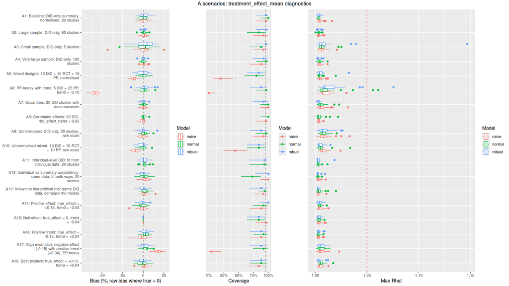

```r
A_combined    <- tar_read(A_combined)
A_agg_combined <- tar_read(A_agg_combined)
plot_diagnostics(A_combined, A_agg_combined, scenario_lookup_tbl, "A")
```

```r
results_table(all_agg, scenario_lookup_tbl, "A")
```

Category A: results

| Scenario | Description | Model | Fit | Parameter | Coverage | Bias | RMSE |
| --- | --- | --- | --- | --- | --- | --- | --- |
| A1 | Baseline: DiD-only summary, normalised, 20 studies | normalised; normal heterogeneity; pooled trend; imbalance by randomisation | default | baseline_difference_sd | 0.000 | 0.015 | 0.016 |
|  |  |  | default | time_trend_mean | 0.960 | -0.002 | 0.010 |
|  |  |  | default | time_trend_sd | 0.880 | 0.005 | 0.010 |
|  |  |  | default | treatment_effect_mean | 1.000 | -0.003 | 0.017 |
|  |  |  | default | treatment_effect_sd | 0.920 | 0.006 | 0.014 |
| A2 | Large sample: DiD-only, 60 studies |  | default | baseline_difference_sd | 0.000 | 0.012 | 0.013 |
|  |  |  | default | time_trend_mean | 0.880 | -0.002 | 0.007 |
|  |  |  | default | time_trend_sd | 0.920 | 0.001 | 0.006 |
|  |  |  | default | treatment_effect_mean | 0.840 | 0.003 | 0.012 |
|  |  |  | default | treatment_effect_sd | 0.720 | 0.006 | 0.011 |
| A3 | Small sample: DiD-only, 5 studies |  | default | baseline_difference_sd | 0.000 | 0.027 | 0.029 |
|  |  |  | default | time_trend_mean | 0.960 | -0.001 | 0.018 |
|  |  |  | default | time_trend_sd | 0.960 | 0.017 | 0.030 |
|  |  |  | default | treatment_effect_mean | 0.880 | 0.001 | 0.040 |
|  |  |  | default | treatment_effect_sd | 0.960 | 0.023 | 0.042 |
| A4 | Very large sample: DiD-only, 100 studies |  | default | baseline_difference_sd | 0.000 | 0.009 | 0.010 |
|  |  |  | default | time_trend_mean | 0.960 | -0.001 | 0.005 |
|  |  |  | default | time_trend_sd | 0.760 | 0.003 | 0.006 |
|  |  |  | default | treatment_effect_mean | 0.960 | 0.000 | 0.009 |
|  |  |  | default | treatment_effect_sd | 0.920 | 0.003 | 0.008 |
| A5 | Mixed designs: 10 DiD + 10 RCT + 10 PP, normalised |  | default | baseline_difference_sd | 0.000 | 0.022 | 0.023 |
|  |  |  | default | time_trend_mean | 0.960 | 0.003 | 0.017 |
|  |  |  | default | time_trend_sd | 0.880 | 0.010 | 0.020 |
|  |  |  | default | treatment_effect_mean | 0.800 | 0.000 | 0.020 |
|  |  |  | default | treatment_effect_sd | 0.880 | -0.003 | 0.016 |
| A6 | PP-heavy with trend: 5 DiD + 25 PP, trend = -0.10 |  | default | baseline_difference_sd | 0.000 | 0.027 | 0.028 |
|  |  |  | default | time_trend_mean | 1.000 | 0.001 | 0.015 |
|  |  |  | default | time_trend_sd | 0.800 | 0.014 | 0.024 |
|  |  |  | default | treatment_effect_mean | 0.960 | 0.000 | 0.020 |
|  |  |  | default | treatment_effect_sd | 0.840 | 0.004 | 0.018 |

[output cut: 73 more lines]

## F. Large-N Bias Probes

```r
scenario_summary_table("F") |>
  kable(caption = "Category F: scenario definitions")
```

Category F: scenario definitions

| ID | Description | DGP overrides | Fit overrides |
| --- | --- | --- | --- |
| F1 | Large mixed, normalised, full model: 35 DiD + 35 RCT + 30 PP | n_did = 35; n_rct = 35; n_pp = 30 | (defaults) |
| F2 | Large mixed, normalised, naive: 70 DiD + 70 RCT + 60 PP (zero trend, equal baselines) | n_did = 70; n_rct = 70; n_pp = 60; true_trend = 0; sigma_trend = 0; baseline_sd = 0 | fn = meta_did_general; time_trend = fixed_zero; baseline_imbalance = fixed_zero |
| F3 | Large mixed, unnormalised: 70 DiD + 70 RCT + 60 PP | n_did = 70; n_rct = 70; n_pp = 60 | normalise = [FALSE] |
| F4 | Large DiD + RCT only: 50 DiD + 50 RCT | n_did = 50; n_rct = 50 | (defaults) |
| F5 | Large DiD + PP only: 100 DiD + 100 PP, nonzero trend | n_did = 100; n_pp = 100; true_trend = -0.1; sigma_trend = 0.01 | (defaults) |
| F6 | Large DiD-only with covariates: 200 studies | n_did = 200 | (defaults) |
| F7 | Large mixed, design effects: 35 DiD + 35 RCT + 30 PP with offsets | n_did = 35; n_rct = 35; n_pp = 30; delta_rct = 0.1; delta_pp = -0.08 | design_effects = [TRUE] |
| F8 | Large DiD-only, correlated effects: 200 studies, rho_effect_trend = 0.95 | n_did = 200; baseline_sd = 0; rho_effect_trend = 0.95 | fn = meta_did_general; correlated_effects = [TRUE] |

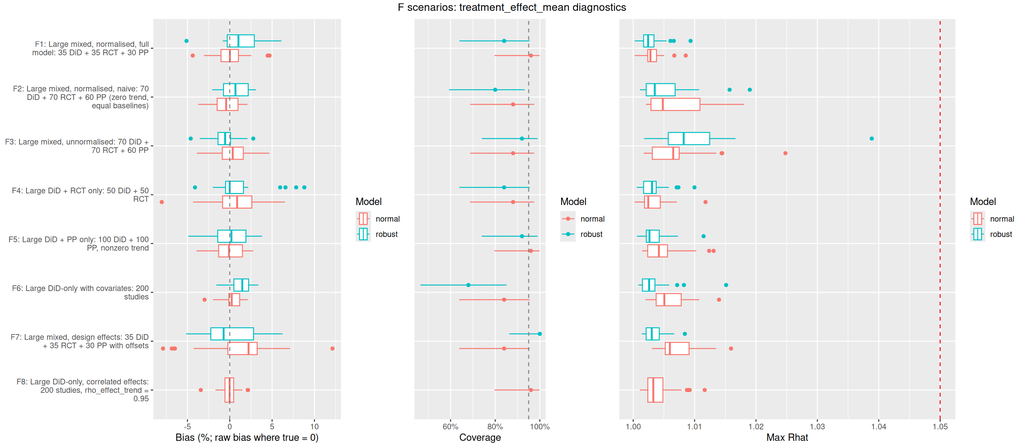

```r
F_combined     <- tar_read(F_combined)
F_agg_combined <- tar_read(F_agg_combined)
plot_diagnostics(F_combined, F_agg_combined, scenario_lookup_tbl, "F")
```

```r
results_table(all_agg, scenario_lookup_tbl, "F")
```

Category F: results

| Scenario | Description | Model | Fit | Parameter | Coverage | Bias | RMSE |
| --- | --- | --- | --- | --- | --- | --- | --- |
| F1 | Large mixed, normalised, full model: 35 DiD + 35 RCT + 30 PP | normalised; normal heterogeneity; pooled trend; imbalance by randomisation | default | baseline_difference_sd | 0.00 | 0.014 | 0.015 |
|  |  |  | default | time_trend_mean | 1.00 | 0.002 | 0.006 |
|  |  |  | default | time_trend_sd | 0.96 | 0.000 | 0.006 |
|  |  |  | default | treatment_effect_mean | 0.96 | 0.001 | 0.007 |
|  |  |  | default | treatment_effect_sd | 0.88 | 0.002 | 0.007 |
| F2 | Large mixed, normalised, naive: 70 DiD + 70 RCT + 60 PP (zero trend, equal baselines) | normalised; normal heterogeneity; zero trend; zero imbalance | default | baseline_difference_sd | 0.00 | 0.010 | 0.010 |
|  |  |  | default | time_trend_mean | 0.76 | -0.001 | 0.005 |
|  |  |  | default | time_trend_sd | 0.00 | 0.007 | 0.007 |
|  |  |  | default | treatment_effect_mean | 0.88 | -0.001 | 0.005 |
|  |  |  | default | treatment_effect_sd | 0.88 | -0.001 | 0.004 |
| F3 | Large mixed, unnormalised: 70 DiD + 70 RCT + 60 PP | unnormalised; normal heterogeneity; pooled trend; imbalance by randomisation | default | baseline_control_mean | 0.88 | 0.000 | 0.006 |
|  |  |  | default | baseline_difference_sd | 0.00 | 0.010 | 0.011 |
|  |  |  | default | time_trend_mean | 0.84 | 0.000 | 0.003 |
|  |  |  | default | time_trend_sd | 1.00 | 0.001 | 0.002 |
|  |  |  | default | treatment_effect_mean | 0.88 | 0.000 | 0.003 |
|  |  |  | default | treatment_effect_sd | 0.88 | 0.000 | 0.002 |
| F4 | Large DiD + RCT only: 50 DiD + 50 RCT | normalised; normal heterogeneity; pooled trend; imbalance by randomisation | default | baseline_difference_sd | 0.00 | 0.011 | 0.011 |
|  |  |  | default | time_trend_mean | 0.88 | -0.001 | 0.007 |
|  |  |  | default | time_trend_sd | 0.72 | 0.001 | 0.008 |
|  |  |  | default | treatment_effect_mean | 0.88 | 0.002 | 0.011 |
|  |  |  | default | treatment_effect_sd | 0.76 | 0.006 | 0.009 |
| F5 | Large DiD + PP only: 100 DiD + 100 PP, nonzero trend |  | default | baseline_difference_sd | 0.00 | 0.009 | 0.010 |
|  |  |  | default | time_trend_mean | 0.92 | -0.001 | 0.004 |
|  |  |  | default | time_trend_sd | 0.64 | 0.004 | 0.006 |
|  |  |  | default | treatment_effect_mean | 0.96 | 0.000 | 0.006 |
|  |  |  | default | treatment_effect_sd | 0.48 | 0.010 | 0.012 |
| F6 | Large DiD-only with covariates: 200 studies |  | default | baseline_difference_sd | 0.00 | 0.008 | 0.008 |
|  |  |  | default | beta_cov[dose] | 0.84 | 0.001 | 0.009 |
|  |  |  | default | time_trend_mean | 1.00 | 0.000 | 0.003 |
|  |  |  | default | time_trend_sd | 0.76 | 0.002 | 0.004 |
|  |  |  | default | treatment_effect_mean | 0.84 | 0.002 | 0.007 |
|  |  |  | default | treatment_effect_sd | 0.12 | 0.018 | 0.019 |
| F7 | Large mixed, design effects: 35 DiD + 35 RCT + 30 PP with offsets | normalised; normal heterogeneity; design effects; pooled trend; imbalance by randomisation | default | baseline_difference_sd | 0.00 | 0.013 | 0.014 |
|  |  |  | default | time_trend_mean | 0.96 | 0.000 | 0.008 |
|  |  |  | default | time_trend_sd | 0.92 | 0.003 | 0.008 |
|  |  |  | default | treatment_effect_mean | 0.84 | 0.004 | 0.016 |
|  |  |  | default | treatment_effect_mean_pp | 0.84 | 0.010 | 0.023 |
|  |  |  | default | treatment_effect_mean_rct | 1.00 | 0.000 | 0.013 |
|  |  |  | default | treatment_effect_sd | 0.96 | 0.001 | 0.006 |
| F8 | Large DiD-only, correlated effects: 200 studies, rho_effect_trend = 0.95 | normalised; normal heterogeneity; correlated effects; pooled trend; imbalance by randomisation | default | baseline_difference_sd | 0.00 | 0.008 | 0.008 |
|  |  |  | default | time_trend_mean | 0.96 | -0.001 | 0.003 |
|  |  |  | default | time_trend_sd | 0.92 | 0.000 | 0.003 |
|  |  |  | default | treatment_effect_mean | 0.96 | 0.000 | 0.004 |
|  |  |  | default | treatment_effect_sd | 0.92 | 0.000 | 0.004 |

## B. Comparative Studies

These scenarios pit two model configurations against each other on the same simulated data, asking which recovers the treatment effect better under specific conditions. Each scenario has a clear hypothesis about which model should win (or whether they should tie).

```r
scenario_summary_table("B") |>
  kable(caption = "Category B: scenario definitions")
```

Category B: scenario definitions

| ID | Description | DGP overrides | Fit overrides |
| --- | --- | --- | --- |
| B1 | Naive vs full: PP-heavy, large trend (full should win) | n_did = 5; n_pp = 25; true_trend = -0.1; sigma_trend = 0.01 | (defaults) |
| B2 | Naive vs full: assumptions satisfied (zero trend, equal baselines) | n_did = 10; n_rct = 10; n_pp = 10; true_trend = 0; sigma_trend = 0; baseline_sd = 0 | (defaults) |
| B3 | Naive wins: DiD trend = 0, PP trend = -0.10 (pooled borrows wrong trend) | n_did = 10; n_pp = 10; did_trend = 0; pp_trend = -0.1 | (defaults) |
| B4 | Correlated vs independent effects: rho_effect_trend = 0.95 | n_did = 30; baseline_sd = 0; rho_effect_trend = 0.95 | (defaults) |
| B5 | Unrandomised post-only imbalance (only in this design): pooled vs zero-mean vs naive, 10 DiD + 10 RCT | n_did = 10; n_rct = 10; rct_gamma_mean = 0.05; rct_gamma_sd = 0.02 | (defaults) |
| B6 | DiD imbalance > post-only imbalance: pooled vs zero-mean vs naive, 15 DiD + 15 RCT | n_did = 15; n_rct = 15; did_gamma_mean = 0.08; did_gamma_sd = 0.02; rct_gamma_mean = 0.01; rct_gamma_sd = 0.01 | (defaults) |

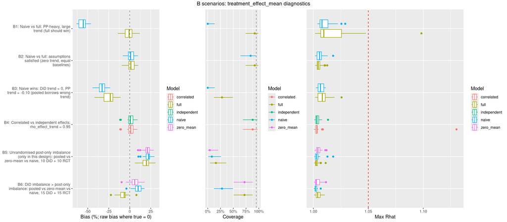

```r
plot_diagnostics(all_rep, all_agg, scenario_lookup_tbl, "B")
```

```r
results_table(all_agg, scenario_lookup_tbl, "B")
```

Category B: results

| Scenario | Description | Model | Fit | Parameter | Coverage | Bias | RMSE |
| --- | --- | --- | --- | --- | --- | --- | --- |
| B1 | Naive vs full: PP-heavy, large trend (full should win) | normalised; normal heterogeneity; pooled trend; imbalance by randomisation | full | baseline_difference_sd | 0.00 | 0.029 | 0.030 |
|  |  |  | full | time_trend_mean | 0.92 | 0.003 | 0.020 |
|  |  |  | full | time_trend_sd | 0.80 | 0.018 | 0.029 |
|  |  |  | full | treatment_effect_mean | 0.92 | -0.002 | 0.025 |
|  |  |  | full | treatment_effect_sd | 0.88 | 0.004 | 0.022 |
|  |  |  | naive | baseline_difference_sd | 0.00 | 0.029 | 0.030 |
|  |  |  | naive | time_trend_mean | 0.92 | 0.009 | 0.023 |
|  |  |  | naive | time_trend_sd | 0.84 | 0.021 | 0.037 |
|  |  |  | naive | treatment_effect_mean | 0.00 | -0.189 | 0.190 |
|  |  |  | naive | treatment_effect_sd | 0.00 | 0.055 | 0.058 |
| B2 | Naive vs full: assumptions satisfied (zero trend, equal baselines) |  | full | baseline_difference_sd | 0.00 | 0.020 | 0.021 |
|  |  |  | full | time_trend_mean | 0.96 | -0.005 | 0.009 |
|  |  |  | full | time_trend_sd | 0.00 | 0.015 | 0.016 |
|  |  |  | full | treatment_effect_mean | 0.92 | 0.005 | 0.017 |
|  |  |  | full | treatment_effect_sd | 0.80 | -0.001 | 0.014 |
|  |  |  | naive | baseline_difference_sd | 0.00 | 0.020 | 0.022 |
|  |  |  | naive | time_trend_mean | 0.96 | -0.006 | 0.008 |
|  |  |  | naive | time_trend_sd | 0.00 | 0.015 | 0.016 |
|  |  |  | naive | treatment_effect_mean | 0.84 | 0.003 | 0.015 |
|  |  |  | naive | treatment_effect_sd | 0.76 | 0.001 | 0.013 |
| B3 | Naive wins: DiD trend = 0, PP trend = -0.10 (pooled borrows wrong trend) |  | full | baseline_difference_sd | 0.00 | 0.021 | 0.022 |
|  |  |  | full | time_trend_mean | 0.36 | 0.064 | 0.068 |
|  |  |  | full | time_trend_sd | 0.92 | 0.013 | 0.026 |
|  |  |  | full | treatment_effect_mean | 0.28 | -0.084 | 0.089 |
|  |  |  | full | treatment_effect_sd | 0.20 | 0.059 | 0.064 |
|  |  |  | naive | baseline_difference_sd | 0.00 | 0.021 | 0.023 |
|  |  |  | naive | time_trend_mean | 0.00 | 0.089 | 0.090 |
|  |  |  | naive | time_trend_sd | 1.00 | 0.001 | 0.013 |
|  |  |  | naive | treatment_effect_mean | 0.00 | -0.111 | 0.112 |
|  |  |  | naive | treatment_effect_sd | 0.00 | 0.078 | 0.081 |
| B4 | Correlated vs independent effects: rho_effect_trend = 0.95 |  | correlated | baseline_difference_sd | 0.00 | 0.012 | 0.013 |
|  |  |  | correlated | time_trend_mean | 0.88 | -0.001 | 0.009 |
|  |  |  | correlated | time_trend_sd | 0.92 | 0.001 | 0.007 |
|  |  |  | correlated | treatment_effect_mean | 0.88 | 0.004 | 0.016 |
|  |  |  | correlated | treatment_effect_sd | 0.92 | 0.003 | 0.012 |
|  |  |  | independent | baseline_difference_sd | 0.00 | 0.012 | 0.013 |
|  |  |  | independent | time_trend_mean | 0.88 | -0.001 | 0.009 |
|  |  |  | independent | time_trend_sd | 0.88 | 0.005 | 0.009 |
|  |  |  | independent | treatment_effect_mean | 0.88 | 0.003 | 0.016 |
|  |  |  | independent | treatment_effect_sd | 0.84 | 0.010 | 0.015 |
| B5 | Unrandomised post-only imbalance (only in this design): pooled vs zero-mean vs naive, 10 DiD + 10 RCT |  | full | time_trend_mean | 0.84 | 0.003 | 0.019 |
|  |  |  | full | time_trend_sd | 0.84 | 0.002 | 0.020 |
|  |  |  | full | treatment_effect_mean | 0.16 | 0.064 | 0.067 |
|  |  |  | full | treatment_effect_sd | 0.60 | 0.026 | 0.034 |
|  |  |  | naive | time_trend_mean | 0.84 | 0.003 | 0.018 |
|  |  |  | naive | time_trend_sd | 0.84 | 0.002 | 0.021 |
|  |  |  | naive | treatment_effect_mean | 0.08 | 0.072 | 0.074 |
|  |  |  | naive | treatment_effect_sd | 0.52 | 0.030 | 0.035 |
|  |  |  | zero_mean | time_trend_mean | 0.84 | 0.002 | 0.018 |
|  |  |  | zero_mean | time_trend_sd | 0.84 | 0.001 | 0.020 |
|  |  |  | zero_mean | treatment_effect_mean | 0.04 | 0.070 | 0.072 |
|  |  |  | zero_mean | treatment_effect_sd | 0.60 | 0.028 | 0.034 |
| B6 | DiD imbalance > post-only imbalance: pooled vs zero-mean vs naive, 15 DiD + 15 RCT |  | full | time_trend_mean | 0.96 | -0.002 | 0.009 |
|  |  |  | full | time_trend_sd | 0.92 | 0.006 | 0.012 |
|  |  |  | full | treatment_effect_mean | 0.72 | -0.027 | 0.034 |
|  |  |  | full | treatment_effect_sd | 0.88 | 0.004 | 0.012 |
|  |  |  | naive | time_trend_mean | 0.96 | 0.001 | 0.010 |
|  |  |  | naive | time_trend_sd | 0.92 | 0.007 | 0.012 |
|  |  |  | naive | treatment_effect_mean | 0.28 | 0.033 | 0.036 |
|  |  |  | naive | treatment_effect_sd | 0.96 | 0.004 | 0.010 |
|  |  | zero_mean | time_trend_mean | 0.96 | 0.001 | 0.010 |  |
|  |  | zero_mean | time_trend_sd | 0.92 | 0.007 | 0.012 |  |
|  |  | zero_mean | treatment_effect_mean | 0.72 | 0.019 | 0.027 |  |
|  |  | zero_mean | treatment_effect_sd | 0.96 | -0.004 | 0.013 |  |

## C. Outlier and Heavy-Tailed Studies

These scenarios test robustness to departures from Gaussian study-level heterogeneity. The contaminating distributions are chosen to be detectable but not catastrophic, so that a robust model (Student-t heterogeneity) should outperform the normal model without being trivially obvious.

```r
scenario_summary_table("C") |>
  kable(caption = "Category C: scenario definitions")
```

Category C: scenario definitions

| ID | Description | DGP overrides | Fit overrides |
| --- | --- | --- | --- |
| C1 | Single outlier: one study shifted by 5*sigma_effect | n_outlier = 1; outlier_shift = 5 | (defaults) |
| C2 | Multiple outliers: 3 of 20 from contaminating distribution | n_outlier = 3; outlier_shift = 5 | (defaults) |
| C3 | Heavy-tailed study effects: theta_i ~ t(df=3) | effect_df = 3 | (defaults) |
| C4 | Heavy-tailed within-study errors: observations ~ t(df=5) | within_df = 5 | (defaults) |
| C5 | Outlier + small sample: single outlier among 5 studies | n_did = 5; n_outlier = 1; outlier_shift = 5 | (defaults) |
| C6 | Asymmetric contamination: outliers all biased in same direction | n_outlier = 3; outlier_shift = 5; outlier_direction = positive | (defaults) |
| C7 | Outlier in one design: 10 DiD + 10 PP, outliers only among PP | n_did = 10; n_pp = 10; n_outlier_pp = 2; outlier_shift = 5 | (defaults) |
| C8 | Heavy-tailed time trends: beta_i ~ t(df=3) | trend_df = 3 | (defaults) |

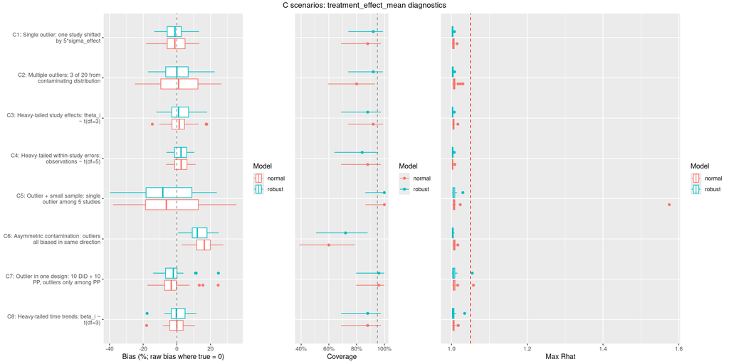

```r
plot_diagnostics(all_rep, all_agg, scenario_lookup_tbl, "C")
```

```r
results_table(all_agg, scenario_lookup_tbl, "C")
```

Category C: results

| Scenario | Description | Model | Fit | Parameter | Coverage | Bias | RMSE |
| --- | --- | --- | --- | --- | --- | --- | --- |
| C1 | Single outlier: one study shifted by 5*sigma_effect | normalised; normal heterogeneity; pooled trend; imbalance by randomisation | normal | baseline_difference_sd | 0.00 | 0.017 | 0.019 |
|  |  |  | normal | time_trend_mean | 0.96 | 0.001 | 0.009 |
|  |  |  | normal | time_trend_sd | 0.92 | 0.006 | 0.012 |
|  |  |  | normal | treatment_effect_mean | 0.88 | -0.003 | 0.027 |
|  |  |  | normal | treatment_effect_sd | 0.32 | 0.036 | 0.043 |
|  |  |  | robust | baseline_difference_sd | 0.00 | 0.017 | 0.018 |
|  |  |  | robust | time_trend_mean | 0.96 | 0.001 | 0.009 |
|  |  |  | robust | time_trend_sd | 0.88 | 0.006 | 0.012 |
|  |  |  | robust | treatment_effect_mean | 0.92 | -0.004 | 0.023 |
|  |  |  | robust | treatment_effect_sd | 0.72 | 0.019 | 0.029 |
| C2 | Multiple outliers: 3 of 20 from contaminating distribution |  | normal | baseline_difference_sd | 0.00 | 0.017 | 0.019 |
|  |  |  | normal | time_trend_mean | 0.88 | 0.002 | 0.012 |
|  |  |  | normal | time_trend_sd | 0.96 | 0.001 | 0.011 |
|  |  |  | normal | treatment_effect_mean | 0.80 | 0.002 | 0.043 |
|  |  |  | normal | treatment_effect_sd | 0.00 | 0.087 | 0.089 |
|  |  |  | robust | baseline_difference_sd | 0.00 | 0.017 | 0.019 |
|  |  |  | robust | time_trend_mean | 0.88 | 0.002 | 0.012 |
|  |  |  | robust | time_trend_sd | 0.92 | 0.002 | 0.011 |
|  |  |  | robust | treatment_effect_mean | 0.92 | 0.004 | 0.034 |
|  |  |  | robust | treatment_effect_sd | 0.24 | 0.059 | 0.061 |
| C3 | Heavy-tailed study effects: theta_i ~ t(df=3) |  | normal | baseline_difference_sd | 0.00 | 0.014 | 0.015 |
|  |  |  | normal | time_trend_mean | 0.92 | -0.001 | 0.010 |
|  |  |  | normal | time_trend_sd | 0.88 | 0.003 | 0.012 |
|  |  |  | normal | treatment_effect_mean | 0.92 | 0.007 | 0.026 |
|  |  |  | normal | treatment_effect_sd | 0.56 | 0.036 | 0.049 |
|  |  |  | robust | baseline_difference_sd | 0.00 | 0.014 | 0.015 |
|  |  |  | robust | time_trend_mean | 0.92 | -0.001 | 0.010 |
|  |  |  | robust | time_trend_sd | 0.88 | 0.003 | 0.012 |
|  |  |  | robust | treatment_effect_mean | 0.88 | 0.008 | 0.025 |
|  |  |  | robust | treatment_effect_sd | 0.80 | 0.026 | 0.036 |
| C4 | Heavy-tailed within-study errors: observations ~ t(df=5) |  | normal | baseline_difference_sd | 0.00 | 0.014 | 0.015 |
|  |  |  | normal | time_trend_mean | 0.96 | -0.001 | 0.012 |
|  |  |  | normal | time_trend_sd | 0.84 | 0.007 | 0.013 |
|  |  |  | normal | treatment_effect_mean | 0.88 | 0.008 | 0.018 |
|  |  |  | normal | treatment_effect_sd | 0.72 | 0.001 | 0.022 |
|  |  |  | robust | baseline_difference_sd | 0.00 | 0.014 | 0.015 |
|  |  |  | robust | time_trend_mean | 0.92 | -0.002 | 0.012 |
|  |  |  | robust | time_trend_sd | 0.76 | 0.007 | 0.013 |
|  |  |  | robust | treatment_effect_mean | 0.84 | 0.008 | 0.017 |
|  |  |  | robust | treatment_effect_sd | 0.88 | -0.004 | 0.020 |
| C5 | Outlier + small sample: single outlier among 5 studies |  | normal | baseline_difference_sd | 0.00 | 0.031 | 0.033 |
|  |  |  | normal | time_trend_mean | 0.96 | 0.009 | 0.021 |
|  |  |  | normal | time_trend_sd | 0.88 | 0.023 | 0.045 |
|  |  |  | normal | treatment_effect_mean | 1.00 | -0.010 | 0.066 |
|  |  |  | normal | treatment_effect_sd | 0.08 | 0.173 | 0.187 |
|  |  |  | robust | baseline_difference_sd | 0.00 | 0.031 | 0.032 |
|  |  |  | robust | time_trend_mean | 0.96 | 0.010 | 0.021 |
|  |  |  | robust | time_trend_sd | 0.88 | 0.022 | 0.046 |
|  |  |  | robust | treatment_effect_mean | 1.00 | -0.017 | 0.060 |
|  |  |  | robust | treatment_effect_sd | 0.20 | 0.158 | 0.165 |
| C6 | Asymmetric contamination: outliers all biased in same direction |  | normal | baseline_difference_sd | 0.00 | 0.017 | 0.018 |
|  |  |  | normal | time_trend_mean | 0.84 | -0.004 | 0.013 |
|  |  |  | normal | time_trend_sd | 0.92 | 0.000 | 0.010 |
|  |  |  | normal | treatment_effect_mean | 0.60 | 0.055 | 0.059 |
|  |  |  | normal | treatment_effect_sd | 0.00 | 0.077 | 0.079 |
|  |  |  | robust | baseline_difference_sd | 0.00 | 0.016 | 0.017 |
|  |  |  | robust | time_trend_mean | 0.84 | -0.004 | 0.013 |
|  |  |  | robust | time_trend_sd | 0.92 | 0.000 | 0.010 |
|  |  |  | robust | treatment_effect_mean | 0.72 | 0.045 | 0.049 |
|  |  |  | robust | treatment_effect_sd | 0.24 | 0.060 | 0.062 |
| C7 | Outlier in one design: 10 DiD + 10 PP, outliers only among PP | normal | baseline_difference_sd | 0.00 | 0.021 | 0.022 |  |
|  |  | normal | time_trend_mean | 0.88 | -0.001 | 0.019 |  |
|  |  | normal | time_trend_sd | 0.84 | 0.017 | 0.028 |  |
|  |  | normal | treatment_effect_mean | 0.96 | -0.007 | 0.032 |  |
|  |  | normal | treatment_effect_sd | 0.32 | 0.057 | 0.064 |  |
|  |  | robust | baseline_difference_sd | 0.00 | 0.021 | 0.022 |  |
|  |  | robust | time_trend_mean | 0.88 | -0.002 | 0.019 |  |
|  |  | robust | time_trend_sd | 0.96 | 0.014 | 0.025 |  |
|  |  | robust | treatment_effect_mean | 0.96 | -0.006 | 0.028 |  |
|  |  | robust | treatment_effect_sd | 0.52 | 0.043 | 0.048 |  |
| C8 | Heavy-tailed time trends: beta_i ~ t(df=3) | normal | baseline_difference_sd | 0.00 | 0.014 | 0.015 |  |
|  |  | normal | time_trend_mean | 0.88 | 0.002 | 0.017 |  |
|  |  | normal | time_trend_sd | 0.32 | 0.030 | 0.039 |  |
|  |  | normal | treatment_effect_mean | 0.88 | -0.001 | 0.022 |  |
|  |  | normal | treatment_effect_sd | 0.84 | 0.009 | 0.018 |  |
|  |  | robust | baseline_difference_sd | 0.00 | 0.014 | 0.015 |  |
|  |  | robust | time_trend_mean | 0.92 | 0.002 | 0.017 |  |
|  |  | robust | time_trend_sd | 0.32 | 0.030 | 0.039 |  |
|  |  | robust | treatment_effect_mean | 0.88 | 0.000 | 0.022 |  |
|  |  | robust | treatment_effect_sd | 0.88 | 0.003 | 0.016 |  |

## D. Assumption Violation Studies

These scenarios introduce deliberate mismatches between the DGP and the fitted model to quantify the cost of specific assumption violations — unmodelled design effects, heterogeneous within-study variance, misspecified rho, effect-size/sample-size correlation, and ignored RCT baseline imbalance.

```r
scenario_summary_table("D") |>
  kable(caption = "Category D: scenario definitions")
```

Category D: scenario definitions

| ID | Description | DGP overrides | Fit overrides |
| --- | --- | --- | --- |
| D1 | Design-specific effects ignored: RCT/PP shifted, design_effects=FALSE | n_did = 10; n_rct = 10; n_pp = 10; delta_rct = 0.1; delta_pp = -0.08 | (defaults) |
| D2 | Heterogeneous within-study variance: sigma_within drawn from Gamma | within_sd_shape = 4; within_sd_rate = 33.3333333333333 | (defaults) |
| D3 | Misspecified rho: true rho varies by study (Beta distribution) | rho_alpha = 5; rho_beta = 5 | (defaults) |
| D4 | Effect heterogeneity correlated with sample size | size_effect_slope = 0.001 | (defaults) |
| D5 | Baseline imbalance in RCT with baseline_imbalance=‘fixed_zero’ | n_did = 10; n_rct = 10; rct_gamma_mean = 0.05; rct_gamma_sd = 0.02 | fn = meta_did_general; baseline_imbalance = fixed_zero |

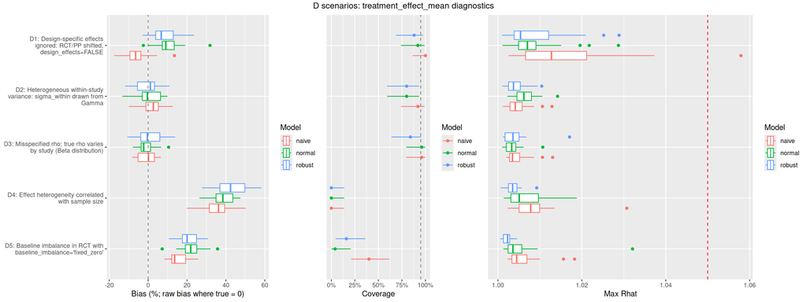

```r
D_combined     <- tar_read(D_combined)
D_agg_combined <- tar_read(D_agg_combined)
plot_diagnostics(D_combined, D_agg_combined, scenario_lookup_tbl, "D")
```

```r
results_table(all_agg, scenario_lookup_tbl, "D")
```

Category D: results

| Scenario | Description | Model | Fit | Parameter | Coverage | Bias | RMSE |
| --- | --- | --- | --- | --- | --- | --- | --- |
| D1 | Design-specific effects ignored: RCT/PP shifted, design_effects=FALSE | normalised; normal heterogeneity; pooled trend; imbalance by randomisation | default | baseline_difference_sd | 0.00 | 0.023 | 0.025 |
|  |  |  | default | time_trend_mean | 0.84 | -0.020 | 0.030 |
|  |  |  | default | time_trend_sd | 0.80 | 0.022 | 0.036 |
|  |  |  | default | treatment_effect_mean | 0.92 | 0.034 | 0.041 |
|  |  |  | default | treatment_effect_sd | 0.00 | 0.101 | 0.104 |
| D2 | Heterogeneous within-study variance: sigma_within drawn from Gamma |  | default | baseline_difference_sd | 0.00 | 0.010 | 0.011 |
|  |  |  | default | time_trend_mean | 0.92 | -0.002 | 0.012 |
|  |  |  | default | time_trend_sd | 0.84 | 0.004 | 0.012 |
|  |  |  | default | treatment_effect_mean | 0.80 | 0.003 | 0.020 |
|  |  |  | default | treatment_effect_sd | 0.80 | 0.002 | 0.018 |
| D3 | Misspecified rho: true rho varies by study (Beta distribution) |  | default | baseline_difference_sd | 0.00 | 0.016 | 0.017 |
|  |  |  | default | time_trend_mean | 0.96 | 0.000 | 0.009 |
|  |  |  | default | time_trend_sd | 0.68 | 0.002 | 0.014 |
|  |  |  | default | treatment_effect_mean | 0.96 | -0.004 | 0.016 |
|  |  |  | default | treatment_effect_sd | 0.88 | 0.005 | 0.015 |
| D4 | Effect heterogeneity correlated with sample size |  | default | baseline_difference_sd | 0.00 | 0.014 | 0.014 |
|  |  |  | default | time_trend_mean | 0.96 | -0.004 | 0.012 |
|  |  |  | default | time_trend_sd | 0.84 | 0.007 | 0.012 |
|  |  |  | default | treatment_effect_mean | 0.00 | 0.130 | 0.132 |
|  |  |  | default | treatment_effect_sd | 0.00 | 0.073 | 0.076 |
| D5 | Baseline imbalance in RCT with baseline_imbalance='fixed_zero' | normalised; normal heterogeneity; pooled trend; zero imbalance | default | time_trend_mean | 0.88 | 0.001 | 0.018 |
|  |  |  | default | time_trend_sd | 0.68 | 0.014 | 0.028 |
|  |  |  | default | treatment_effect_mean | 0.04 | 0.073 | 0.076 |
|  |  |  | default | treatment_effect_sd | 0.44 | 0.033 | 0.038 |

## E. Edge Cases

These scenarios probe boundary conditions: extreme pre-post correlations, zero heterogeneity, very large heterogeneity, unbalanced arms, single studies per design, and missing rho values. They test whether the model remains stable and well-calibrated when inputs approach the limits of the assumed data-generating regime.

```r
scenario_summary_table("E") |>
  kable(caption = "Category E: scenario definitions")
```

Category E: scenario definitions

| ID | Description | DGP overrides | Fit overrides |
| --- | --- | --- | --- |
| E1 | Extreme rho: pre-post correlation near 0 and near 1 | rho_values = [0.02, 0.98] | (defaults) |
| E2 | Zero heterogeneity: all studies have identical true effect | sigma_effect = 0; sigma_trend = 0; baseline_sd = 0 | (defaults) |
| E3 | Large heterogeneity: tau >> typical effect size | sigma_effect = 0.3; sigma_trend = 0.1 | (defaults) |
| E4 | Unbalanced arms: n_treatment = 200, n_control = 30 | n_control = 30; n_treatment = 200 | (defaults) |
| E5 | Single study per design: 1 DiD + 1 RCT + 1 PP | n_did = 1; n_rct = 1; n_pp = 1 | (defaults) |
| E6 | Partial rho: hierarchical_rho imputes the missing half from the reported half | (defaults) | provide_rho = 0.5 |

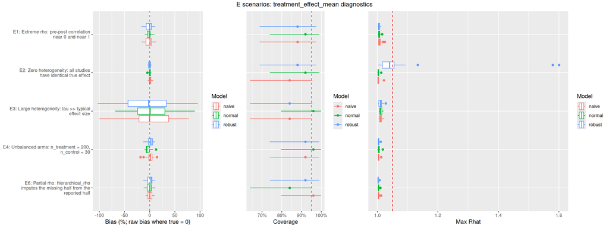

```r
E_combined     <- tar_read(E_combined)
E_agg_combined <- tar_read(E_agg_combined)
plot_diagnostics(E_combined, E_agg_combined, scenario_lookup_tbl, "E", exclude = "E5")
```

```r
results_table(all_agg, scenario_lookup_tbl, "E")
```

Category E: results

| Scenario | Description | Model | Fit | Parameter | Coverage | Bias | RMSE |
| --- | --- | --- | --- | --- | --- | --- | --- |
| E1 | Extreme rho: pre-post correlation near 0 and near 1 | normalised; normal heterogeneity; pooled trend; imbalance by randomisation | default | baseline_difference_sd | 0.00 | 0.015 | 0.015 |
|  |  |  | default | time_trend_mean | 0.84 | -0.001 | 0.014 |
|  |  |  | default | time_trend_sd | 0.96 | 0.005 | 0.009 |
|  |  |  | default | treatment_effect_mean | 0.92 | -0.004 | 0.017 |
|  |  |  | default | treatment_effect_sd | 0.80 | 0.008 | 0.019 |
| E2 | Zero heterogeneity: all studies have identical true effect |  | default | baseline_difference_sd | 0.00 | 0.013 | 0.014 |
|  |  |  | default | time_trend_mean | 0.88 | 0.000 | 0.005 |
|  |  |  | default | time_trend_sd | 0.00 | 0.007 | 0.008 |
|  |  |  | default | treatment_effect_mean | 0.92 | -0.001 | 0.007 |
|  |  |  | default | treatment_effect_sd | 0.00 | 0.009 | 0.009 |
| E3 | Large heterogeneity: tau >> typical effect size |  | default | baseline_difference_sd | 0.00 | 0.018 | 0.019 |
|  |  |  | default | time_trend_mean | 0.80 | -0.008 | 0.056 |
|  |  |  | default | time_trend_sd | 0.84 | 0.009 | 0.045 |
|  |  |  | default | treatment_effect_mean | 0.96 | 0.012 | 0.132 |
|  |  |  | default | treatment_effect_sd | 0.92 | 0.045 | 0.114 |
| E4 | Unbalanced arms: n_treatment = 200, n_control = 30 |  | default | baseline_difference_sd | 0.00 | 0.023 | 0.026 |
|  |  |  | default | time_trend_mean | 0.96 | 0.000 | 0.013 |
|  |  |  | default | time_trend_sd | 0.88 | 0.005 | 0.017 |
|  |  |  | default | treatment_effect_mean | 0.96 | -0.012 | 0.021 |
|  |  |  | default | treatment_effect_sd | 0.76 | 0.008 | 0.022 |
| E5 | Single study per design: 1 DiD + 1 RCT + 1 PP |  | default | baseline_difference_sd | 0.00 | 0.077 | 0.081 |
|  |  |  | default | time_trend_mean | 1.00 | -0.118 | 0.508 |
|  |  |  | default | time_trend_sd | 0.76 | 1.168 | 1.385 |
|  |  |  | default | treatment_effect_mean | 1.00 | 0.077 | 0.325 |
|  |  |  | default | treatment_effect_sd | 0.96 | 0.787 | 0.915 |
| E6 | Partial rho: hierarchical_rho imputes the missing half from the reported half |  | default | baseline_difference_sd | 0.00 | 0.018 | 0.020 |
|  |  |  | default | time_trend_mean | 0.92 | 0.000 | 0.010 |
|  |  |  | default | time_trend_sd | 0.80 | -0.001 | 0.013 |
|  |  |  | default | treatment_effect_mean | 0.84 | 0.000 | 0.021 |
|  |  |  | default | treatment_effect_sd | 0.84 | 0.009 | 0.018 |

## H. Time Trend Distributional Misspecification

The full model assumes study-level time trends are exchangeable draws from a normal distribution. These scenarios test what happens when that assumption is violated at the population level, using a 15 DiD + 15 PP design so that PP studies — which rely on trend estimation for effect identification — are directly exposed to the misspecification. Each scenario compares three models on the same simulated data: the **full normal** model (`meta_did`), the **full robust** model (`meta_did` with Student-t heterogeneity), and the **naive** model (`meta_did_general` with `time_trend = "fixed_zero"`).

```r
scenario_summary_table("H") |>
  kable(caption = "Category H: scenario definitions")
```

Category H: scenario definitions

| ID | Description | DGP overrides | Fit overrides |
| --- | --- | --- | --- |
| H1 | Skewed trends: beta_i ~ -LogNormal (mean = -0.04, log-SD = 1), 15 DiD + 15 PP | n_did = 15; n_pp = 15; sigma_trend = 0.052; lognormal_sigma = 1 | (defaults) |
| H2 | Bimodal trends: 50/50 mixture N(-0.10, 0.01) + N(-0.01, 0.01), 15 DiD + 15 PP | n_did = 15; n_pp = 15; true_trend = -0.055; sigma_trend = 0.046; trend_low = -0.1; trend_high = -0.01; mix_prob = 0.5; sigma_within = 0.01 | (defaults) |
| H3 | Large trend variance: sigma_trend = 0.10 (5x default), 15 DiD + 15 PP | n_did = 15; n_pp = 15; sigma_trend = 0.1 | (defaults) |
| H4 | Trend-size confounding: DiD n ~ U(30,70), PP n ~ U(150,250), 15 DiD + 15 PP | n_did = 15; n_pp = 15; trend_size_slope = 3e-04; n_small_min = 30; n_small_max = 70; n_large_min = 150; n_large_max = 250 | (defaults) |

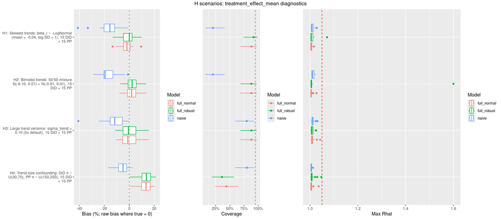

```r
plot_diagnostics(all_rep, all_agg, scenario_lookup_tbl, "H")
```

```r
results_table(all_agg, scenario_lookup_tbl, "H")
```

Category H: results

| Scenario | Description | Model | Fit | Parameter | Coverage | Bias | RMSE |
| --- | --- | --- | --- | --- | --- | --- | --- |
| H1 | Skewed trends: beta_i ~ -LogNormal (mean = -0.04, log-SD = 1), 15 DiD + 15 PP | normalised; normal heterogeneity; pooled trend; imbalance by randomisation | full_normal | baseline_difference_sd | 0.00 | 0.017 | 0.018 |
|  |  |  | full_normal | time_trend_mean | 0.72 | 0.000 | 0.038 |
|  |  |  | full_normal | time_trend_sd | 0.48 | 0.009 | 0.097 |
|  |  |  | full_normal | treatment_effect_mean | 0.88 | -0.007 | 0.018 |
|  |  |  | full_normal | treatment_effect_sd | 0.80 | 0.013 | 0.029 |
|  |  |  | full_robust | baseline_difference_sd | 0.00 | 0.017 | 0.018 |
|  |  |  | full_robust | time_trend_mean | 0.72 | 0.005 | 0.032 |
|  |  |  | full_robust | time_trend_sd | 0.40 | -0.011 | 0.061 |
|  |  |  | full_robust | treatment_effect_mean | 0.92 | -0.004 | 0.017 |
|  |  |  | full_robust | treatment_effect_sd | 0.84 | 0.003 | 0.021 |
|  |  |  | naive | baseline_difference_sd | 0.00 | 0.017 | 0.018 |
|  |  |  | naive | time_trend_mean | 0.76 | 0.007 | 0.034 |
|  |  |  | naive | time_trend_sd | 0.44 | -0.001 | 0.081 |
|  |  |  | naive | treatment_effect_mean | 0.20 | -0.055 | 0.062 |
|  |  |  | naive | treatment_effect_sd | 0.24 | 0.070 | 0.110 |
| H2 | Bimodal trends: 50/50 mixture N(-0.10, 0.01) + N(-0.01, 0.01), 15 DiD + 15 PP |  | full_normal | baseline_difference_sd | 0.00 | 0.017 | 0.018 |
|  |  |  | full_normal | time_trend_mean | 1.00 | 0.001 | 0.013 |
|  |  |  | full_normal | time_trend_sd | 1.00 | 0.011 | 0.016 |
|  |  |  | full_normal | treatment_effect_mean | 0.88 | 0.007 | 0.019 |
|  |  |  | full_normal | treatment_effect_sd | 0.92 | 0.004 | 0.017 |
|  |  |  | full_robust | baseline_difference_sd | 0.00 | 0.017 | 0.018 |
|  |  |  | full_robust | time_trend_mean | 1.00 | 0.001 | 0.014 |
|  |  |  | full_robust | time_trend_sd | 0.96 | 0.012 | 0.016 |
|  |  |  | full_robust | treatment_effect_mean | 0.88 | 0.009 | 0.018 |
|  |  |  | full_robust | treatment_effect_sd | 0.96 | -0.003 | 0.017 |
|  |  |  | naive | baseline_difference_sd | 0.00 | 0.016 | 0.017 |
|  |  |  | naive | time_trend_mean | 0.88 | 0.010 | 0.024 |
|  |  |  | naive | time_trend_sd | 1.00 | 0.015 | 0.021 |
|  |  |  | naive | treatment_effect_mean | 0.20 | -0.058 | 0.063 |
|  |  |  | naive | treatment_effect_sd | 0.00 | 0.057 | 0.059 |
| H3 | Large trend variance: sigma_trend = 0.10 (5x default), 15 DiD + 15 PP |  | full_normal | baseline_difference_sd | 0.00 | 0.018 | 0.020 |
|  |  |  | full_normal | time_trend_mean | 0.84 | 0.004 | 0.049 |
|  |  |  | full_normal | time_trend_sd | 0.92 | 0.011 | 0.034 |
|  |  |  | full_normal | treatment_effect_mean | 0.88 | 0.001 | 0.022 |
|  |  |  | full_normal | treatment_effect_sd | 0.92 | 0.003 | 0.020 |
|  |  |  | full_robust | baseline_difference_sd | 0.00 | 0.019 | 0.020 |
|  |  |  | full_robust | time_trend_mean | 0.88 | 0.004 | 0.049 |
|  |  |  | full_robust | time_trend_sd | 0.92 | 0.011 | 0.034 |
|  |  |  | full_robust | treatment_effect_mean | 0.88 | 0.001 | 0.022 |
|  |  |  | full_robust | treatment_effect_sd | 0.88 | -0.001 | 0.019 |
|  |  |  | naive | baseline_difference_sd | 0.00 | 0.019 | 0.021 |
|  |  |  | naive | time_trend_mean | 0.96 | 0.002 | 0.054 |
|  |  |  | naive | time_trend_sd | 0.80 | 0.022 | 0.059 |
|  |  |  | naive | treatment_effect_mean | 0.80 | -0.041 | 0.050 |
|  |  |  | naive | treatment_effect_sd | 0.00 | 0.116 | 0.120 |
| H4 | Trend-size confounding: DiD n ~ U(30,70), PP n ~ U(150,250), 15 DiD + 15 PP |  | full_normal | baseline_difference_sd | 0.00 | 0.024 | 0.025 |
|  |  |  | full_normal | time_trend_mean | 0.36 | -0.038 | 0.042 |
|  |  |  | full_normal | time_trend_sd | 0.84 | 0.008 | 0.017 |
|  |  |  | full_normal | treatment_effect_mean | 0.44 | 0.043 | 0.047 |
|  |  |  | full_normal | treatment_effect_sd | 0.68 | 0.015 | 0.027 |
|  |  |  | full_robust | baseline_difference_sd | 0.00 | 0.024 | 0.025 |
|  |  |  | full_robust | time_trend_mean | 0.36 | -0.037 | 0.041 |
|  |  |  | full_robust | time_trend_sd | 0.80 | 0.009 | 0.017 |
|  |  |  | full_robust | treatment_effect_mean | 0.36 | 0.043 | 0.047 |
|  |  |  | full_robust | treatment_effect_sd | 0.88 | 0.009 | 0.023 |
|  |  |  | naive | baseline_difference_sd | 0.00 | 0.022 | 0.023 |
|  |  |  | naive | time_trend_mean | 0.12 | -0.047 | 0.050 |
|  |  |  | naive | time_trend_sd | 0.88 | 0.003 | 0.014 |
|  |  |  | naive | treatment_effect_mean | 0.80 | -0.019 | 0.025 |
|  |  |  | naive | treatment_effect_sd | 0.60 | 0.019 | 0.024 |

## G. Bias Source Investigation

Category G probes the two systematic bias sources identified in the large-N results (Category F). It comprises two sub-investigations.

**G1–G5: Prior sensitivity (unnormalised model).** The unnormalised model showed a small positive bias (~0.6–0.9%) for a negative true effect, consistent with hierarchical shrinkage toward zero from the default `N(0, 10)` prior on `treatment_effect_mean`. G1–G5 vary the prior standard deviation from 1 to 100 (G3 replicates the default) to test whether the bias decreases monotonically as the prior becomes more diffuse.

**G6–G9: Jensen’s inequality (normalised model).** The normalised model showed ~1% systematic downward bias at 200 studies, consistent with Jensen’s inequality on the ratio estimator: because the model fits E[θ/baseline] rather than E[θ]/E[baseline], the convexity of the reciprocal function induces a negative shift proportional to between-study baseline variance. G6–G8 vary between-study baseline variation (`baseline_sd` = 0, 0.01, 0.10) to confirm that the bias tracks the Jensen term; G9 uses a very large control group (`n_control = 5000`) to test whether high within-study precision alone eliminates the bias.

```r
scenario_summary_table("G") |>
  kable(caption = "Category G: scenario definitions")
```

Category G: scenario definitions

| ID | Description | DGP overrides | Fit overrides |
| --- | --- | --- | --- |
| G1 | Prior sensitivity: effect/trend prior sd = 1 (unnormalised, 20 DiD) | (defaults) | normalise = [FALSE]; priors = [list(dist = “normal”, mean = 0, sd = 1), list(dist = “cauchy”, scale = 5), list(dist = “normal”, mean = 0, sd = 1), list(dist = “cauchy”, scale = 5), list(dist = “normal… |
| G2 | Prior sensitivity: effect/trend prior sd = 5 (unnormalised, 20 DiD) | (defaults) | normalise = [FALSE]; priors = [list(dist = “normal”, mean = 0, sd = 5), list(dist = “cauchy”, scale = 5), list(dist = “normal”, mean = 0, sd = 5), list(dist = “cauchy”, scale = 5), list(dist = “normal… |
| G3 | Prior sensitivity: effect/trend prior sd = 10 (default, unnormalised, 20 DiD) | (defaults) | normalise = [FALSE]; priors = [list(dist = “normal”, mean = 0, sd = 10), list(dist = “cauchy”, scale = 5), list(dist = “normal”, mean = 0, sd = 10), list(dist = “cauchy”, scale = 5), list(dist = “norm… |
| G4 | Prior sensitivity: effect/trend prior sd = 50 (unnormalised, 20 DiD) | (defaults) | normalise = [FALSE]; priors = [list(dist = “normal”, mean = 0, sd = 50), list(dist = “cauchy”, scale = 5), list(dist = “normal”, mean = 0, sd = 50), list(dist = “cauchy”, scale = 5), list(dist = “norm… |
| G5 | Prior sensitivity: effect/trend prior sd = 100 (unnormalised, 20 DiD) | (defaults) | normalise = [FALSE]; priors = [list(dist = “normal”, mean = 0, sd = 100), list(dist = “cauchy”, scale = 5), list(dist = “normal”, mean = 0, sd = 100), list(dist = “cauchy”, scale = 5), list(dist = “no… |
| G6 | Jensen’s test: baseline_sd = 0, no between-study variation (200 DiD) | n_did = 200; baseline_sd = 0 | (defaults) |
| G7 | Jensen’s test: baseline_sd = 0.01, reduced variation (200 DiD) | n_did = 200; baseline_sd = 0.01 | (defaults) |
| G8 | Jensen’s test: baseline_sd = 0.10, amplified variation (100 DiD) | n_did = 100; baseline_sd = 0.1 | (defaults) |
| G9 | Jensen’s test: n_control = 5000, high within-study precision (100 DiD) | n_did = 100; n_control = 5000 | (defaults) |

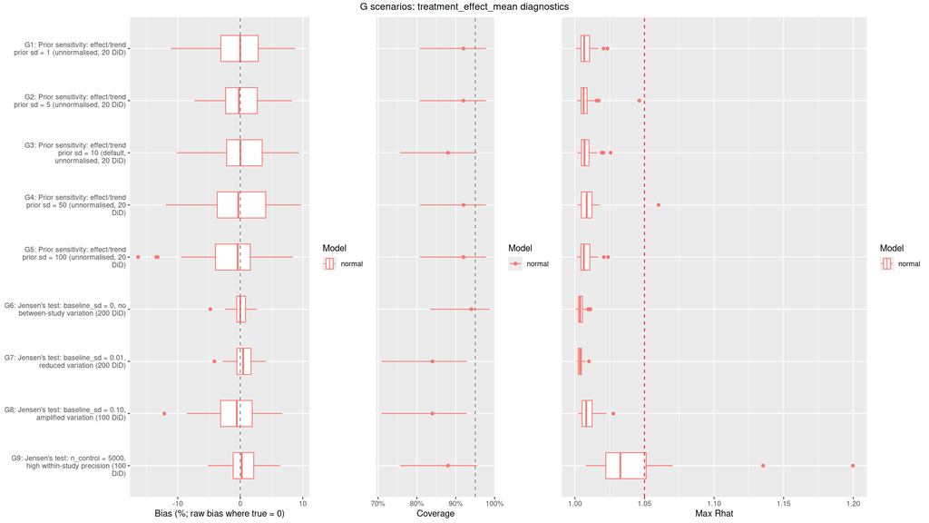

```r
plot_diagnostics(all_rep, all_agg, scenario_lookup_tbl, "G")
```

```r
results_table(all_agg, scenario_lookup_tbl, "G")
```

Category G: results

| Scenario | Description | Model | Fit | Parameter | Coverage | Bias | RMSE |
| --- | --- | --- | --- | --- | --- | --- | --- |
| G1 | Prior sensitivity: effect/trend prior sd = 1 (unnormalised, 20 DiD) | unnormalised; normal heterogeneity; pooled trend; imbalance by randomisation | default | baseline_control_mean | 0.84 | 0.003 | 0.012 |
|  |  |  | default | baseline_difference_sd | 0.00 | 0.016 | 0.017 |
|  |  |  | default | time_trend_mean | 0.92 | 0.001 | 0.005 |
|  |  |  | default | time_trend_sd | 0.96 | 0.001 | 0.004 |
|  |  |  | default | treatment_effect_mean | 0.92 | 0.000 | 0.006 |
|  |  |  | default | treatment_effect_sd | 0.88 | 0.000 | 0.007 |
| G2 | Prior sensitivity: effect/trend prior sd = 5 (unnormalised, 20 DiD) |  | default | baseline_control_mean | 0.82 | 0.002 | 0.014 |
|  |  |  | default | baseline_difference_sd | 0.00 | 0.017 | 0.018 |
|  |  |  | default | time_trend_mean | 1.00 | -0.001 | 0.005 |
|  |  |  | default | time_trend_sd | 0.90 | 0.000 | 0.004 |
|  |  |  | default | treatment_effect_mean | 0.92 | 0.000 | 0.006 |
|  |  |  | default | treatment_effect_sd | 0.92 | 0.000 | 0.007 |
| G3 | Prior sensitivity: effect/trend prior sd = 10 (default, unnormalised, 20 DiD) |  | default | baseline_control_mean | 0.80 | 0.001 | 0.015 |
|  |  |  | default | baseline_difference_sd | 0.00 | 0.015 | 0.016 |
|  |  |  | default | time_trend_mean | 0.86 | -0.002 | 0.006 |
|  |  |  | default | time_trend_sd | 0.88 | 0.002 | 0.005 |
|  |  |  | default | treatment_effect_mean | 0.88 | 0.001 | 0.007 |
|  |  |  | default | treatment_effect_sd | 0.94 | 0.002 | 0.006 |
| G4 | Prior sensitivity: effect/trend prior sd = 50 (unnormalised, 20 DiD) |  | default | baseline_control_mean | 0.80 | 0.000 | 0.014 |
|  |  |  | default | baseline_difference_sd | 0.00 | 0.016 | 0.017 |
|  |  |  | default | time_trend_mean | 0.90 | -0.001 | 0.005 |
|  |  |  | default | time_trend_sd | 0.86 | 0.001 | 0.005 |
|  |  |  | default | treatment_effect_mean | 0.92 | 0.000 | 0.008 |
|  |  |  | default | treatment_effect_sd | 0.88 | 0.003 | 0.008 |
| G5 | Prior sensitivity: effect/trend prior sd = 100 (unnormalised, 20 DiD) |  | default | baseline_control_mean | 0.90 | 0.003 | 0.013 |
|  |  |  | default | baseline_difference_sd | 0.00 | 0.015 | 0.016 |
|  |  |  | default | time_trend_mean | 0.90 | 0.000 | 0.005 |
|  |  |  | default | time_trend_sd | 0.90 | 0.000 | 0.005 |
|  |  |  | default | treatment_effect_mean | 0.92 | -0.002 | 0.008 |
|  |  |  | default | treatment_effect_sd | 0.90 | 0.000 | 0.006 |
| G6 | Jensen's test: baseline_sd = 0, no between-study variation (200 DiD) | normalised; normal heterogeneity; pooled trend; imbalance by randomisation | default | baseline_difference_sd | 0.00 | 0.009 | 0.010 |
|  |  |  | default | time_trend_mean | 0.90 | -0.001 | 0.004 |
|  |  |  | default | time_trend_sd | 0.84 | 0.000 | 0.003 |
|  |  |  | default | treatment_effect_mean | 0.94 | 0.000 | 0.005 |
|  |  |  | default | treatment_effect_sd | 0.86 | 0.000 | 0.004 |
| G7 | Jensen's test: baseline_sd = 0.01, reduced variation (200 DiD) |  | default | baseline_difference_sd | 0.00 | 0.008 | 0.009 |
|  |  |  | default | time_trend_mean | 0.86 | -0.001 | 0.004 |
|  |  |  | default | time_trend_sd | 0.92 | 0.000 | 0.002 |
|  |  |  | default | treatment_effect_mean | 0.84 | 0.002 | 0.006 |
|  |  |  | default | treatment_effect_sd | 0.96 | 0.000 | 0.004 |
| G8 | Jensen's test: baseline_sd = 0.10, amplified variation (100 DiD) |  | default | baseline_difference_sd | 0.00 | 0.010 | 0.010 |
|  |  |  | default | time_trend_mean | 0.96 | -0.001 | 0.006 |
|  |  |  | default | time_trend_sd | 0.56 | 0.008 | 0.010 |
|  |  |  | default | treatment_effect_mean | 0.84 | -0.003 | 0.014 |
|  |  |  | default | treatment_effect_sd | 0.38 | 0.018 | 0.023 |
| G9 | Jensen's test: n_control = 5000, high within-study precision (100 DiD) |  | default | baseline_difference_sd | 0.00 | 0.007 | 0.008 |
|  |  |  | default | time_trend_mean | 0.90 | -0.001 | 0.004 |
|  |  |  | default | time_trend_sd | 0.92 | 0.001 | 0.003 |
|  |  |  | default | treatment_effect_mean | 0.88 | 0.002 | 0.009 |
|  |  |  | default | treatment_effect_sd | 0.82 | 0.003 | 0.008 |

## I. Multiplicative Covariate Scenarios

Category I tests the multiplicative-covariate feature on the metadid `multiplicative-covars` branch: an estimated per-level factor (`effect_multiplier[<level>]`, with the reference level fixed at 1) applied to the population-mean linear predictor `treatment_effect_mean + X_cov · beta_cov`. Per-study heterogeneity is centred on the multiplied mean. The feature is useful when some study settings represent an attenuated or amplified version of the underlying effect (e.g. experimental vs real-world conditions, drug formulation, study source).

Every I scenario pairs a modelled-mode fit (`normalise = TRUE`) with a raw-scale fit (`normalise = FALSE`) via the `compare` block so we can read the multiplier-recovery signal on both scales — the one exception is I7 (individual-level data), which runs the modelled arm only: on the raw scale the individual-data + multiplicative posterior fails to converge and hits max treedepth every iteration, so the arm was dropped (the raw multiplier signal is already covered by I1/I2/I8/I9). I5 and I6 additionally pair with-multiplier vs without-multiplier fits to quantify the misspecification cost of omitting the feature when truth has it (I5) and the false-positive cost of including it spuriously when truth doesn’t (I6). All scenarios use a bespoke simulator (`simulate_multiplicative_levels`) that draws per-study true effects from `θ_i ~ N(m_{level(i)} · (μ_θ + X_cov_i · β_cov), σ_θ²)`.

I8 and I9 exercise the two-covariate product extension (`multiplicative_covariate = ~ level + level2`): each study’s overall factor is the product of two independently estimated per-covariate factors, labelled `effect_multiplier[<column>:<level>]` in the posterior. I8 crosses two binary covariates — one attenuating (0.6), one amplifying (1.4), so the amplifying direction is covered too — and I9 crosses a binary attenuator with a three-level covariate (0.7, 0.4), testing simultaneous recovery of three factors from a fully crossed design. The key diagnostics are per-factor coverage and the absence of leakage between the two factors (each multiplier should recover its own truth, not a blend of the product).

```r
scenario_summary_table("I") |>
  kable(caption = "Category I: scenario definitions")
```

Category I: scenario definitions

| ID | Description | DGP overrides | Fit overrides |
| --- | --- | --- | --- |
| I1 | Multiplicative covariate: binary balanced, 20 DiD | level_assignments = [1, 2, 1, 2, 1, 2, 1, 2, 1, 2, 1, 2, 1, 2, 1, 2, 1, 2, 1, 2]; level_multipliers = [1, 0.6] | multiplicative_covariate = level |
| I2 | Multiplicative covariate: three-level categorical, 30 DiD | n_did = 30; level_assignments = [1, 2, 3, 1, 2, 3, 1, 2, 3, 1, 2, 3, 1, 2, 3, 1, 2, 3, 1, 2, 3, 1, 2, 3, 1, 2, 3, 1, 2, 3]; level_multipliers = [1, 0.7, 0.4] | multiplicative_covariate = level |
| I3 | Multiplicative + additive: binary multiplier × continuous dose, 30 DiD | n_did = 30; level_assignments = [1, 2, 1, 2, 1, 2, 1, 2, 1, 2, 1, 2, 1, 2, 1, 2, 1, 2, 1, 2, 1, 2, 1, 2, 1, 2, 1, 2, 1, 2]; level_multipliers = [1, 0.6] | multiplicative_covariate = level |
| I4 | Multiplicative covariate: mixed designs (10 DiD + 10 RCT + 10 PP), binary | n_did = 10; n_rct = 10; n_pp = 10; level_assignments = [1, 2, 1, 2, 1, 2, 1, 2, 1, 2, 1, 2, 1, 2, 1, 2, 1, 2, 1, 2, 1, 2, 1, 2, 1, 2, 1, 2, 1, 2]; level_multipliers = [1, 0.6] | multiplicative_covariate = level |
| I5 | Omit-multiplier misspecification: truth has binary multiplier, fit with vs without (× modelled/raw) | n_did = 30; level_assignments = [1, 2, 1, 2, 1, 2, 1, 2, 1, 2, 1, 2, 1, 2, 1, 2, 1, 2, 1, 2, 1, 2, 1, 2, 1, 2, 1, 2, 1, 2]; level_multipliers = [1, 0.6] | (defaults) |
| I6 | Spurious multiplier: truth has NO multiplicative effect, fit with vs without (× modelled/raw) | n_did = 30; level_assignments = [1, 2, 1, 2, 1, 2, 1, 2, 1, 2, 1, 2, 1, 2, 1, 2, 1, 2, 1, 2, 1, 2, 1, 2, 1, 2, 1, 2, 1, 2]; level_multipliers = [1, 1] | (defaults) |
| I7 | Multiplicative covariate, individual-level data, 20 DiD | level_assignments = [1, 2, 1, 2, 1, 2, 1, 2, 1, 2, 1, 2, 1, 2, 1, 2, 1, 2, 1, 2]; level_multipliers = [1, 0.6] | multiplicative_covariate = level; data_format = individual |
| I8 | Two-multiplier product: binary (1, 0.6) × binary (1, 1.4), 30 DiD | n_did = 30; level_assignments = [1, 2, 1, 2, 1, 2, 1, 2, 1, 2, 1, 2, 1, 2, 1, 2, 1, 2, 1, 2, 1, 2, 1, 2, 1, 2, 1, 2, 1, 2]; level_multipliers = [1, 0.6]; level2_assignments = [1, 1, 2, 2, 1, 1, 2, 2, … | multiplicative_covariate = [~, level + level2] |
| I9 | Two-multiplier product: binary (1, 0.6) × three-level (1, 0.7, 0.4), 30 DiD | n_did = 30; level_assignments = [1, 2, 1, 2, 1, 2, 1, 2, 1, 2, 1, 2, 1, 2, 1, 2, 1, 2, 1, 2, 1, 2, 1, 2, 1, 2, 1, 2, 1, 2]; level_multipliers = [1, 0.6]; level2_assignments = [1, 1, 2, 2, 3, 3, 1, 1, … | multiplicative_covariate = [~, level + level2] |

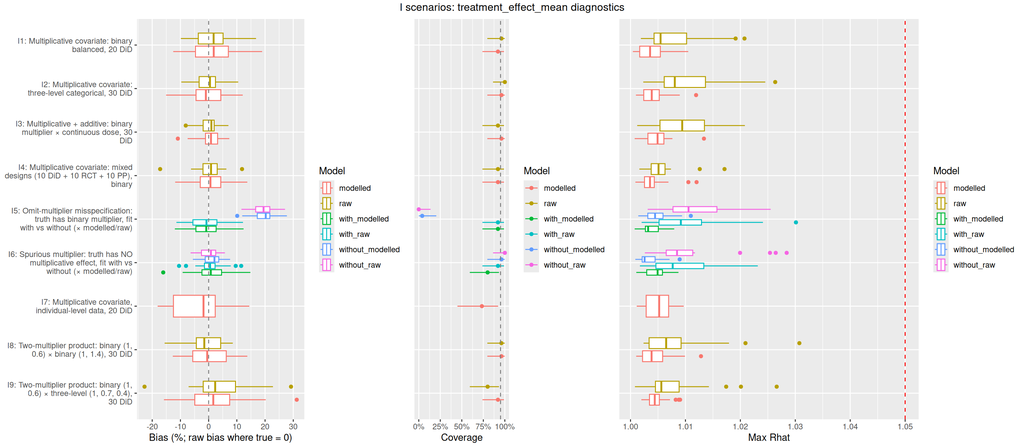

```r
plot_diagnostics(all_rep, all_agg, scenario_lookup_tbl, "I")
```

```r
results_table(all_agg, scenario_lookup_tbl, "I")
```

Category I: results

| Scenario | Description | Model | Fit | Parameter | Coverage | Bias | RMSE |
| --- | --- | --- | --- | --- | --- | --- | --- |
| I1 | Multiplicative covariate: binary balanced, 20 DiD | normalised; normal heterogeneity; pooled trend; imbalance by randomisation | modelled | baseline_difference_sd | 0.000 | 0.017 | 0.018 |
|  |  |  | modelled | effect_multiplier[b] | 0.920 | 0.029 | 0.094 |
|  |  |  | modelled | time_trend_mean | 0.880 | -0.001 | 0.014 |
|  |  |  | modelled | time_trend_sd | 0.880 | 0.007 | 0.011 |
|  |  |  | modelled | treatment_effect_mean | 0.920 | 0.003 | 0.027 |
|  |  |  | modelled | treatment_effect_sd | 0.800 | 0.003 | 0.019 |
|  |  |  | raw | baseline_control_mean | 0.920 | -0.002 | 0.011 |
|  |  |  | raw | baseline_difference_sd | 0.000 | 0.016 | 0.018 |
|  |  |  | raw | effect_multiplier[b] | 0.880 | 0.031 | 0.087 |
|  |  |  | raw | time_trend_mean | 0.840 | 0.000 | 0.006 |
|  |  |  | raw | time_trend_sd | 0.920 | 0.002 | 0.004 |
|  |  |  | raw | treatment_effect_mean | 0.960 | 0.002 | 0.010 |
|  |  |  | raw | treatment_effect_sd | 0.800 | 0.002 | 0.009 |
| I2 | Multiplicative covariate: three-level categorical, 30 DiD |  | modelled | baseline_difference_sd | 0.000 | 0.013 | 0.014 |
|  |  |  | modelled | effect_multiplier[b] | 0.840 | 0.003 | 0.091 |
|  |  |  | modelled | effect_multiplier[c] | 0.960 | 0.029 | 0.068 |
|  |  |  | modelled | time_trend_mean | 0.920 | 0.000 | 0.008 |
|  |  |  | modelled | time_trend_sd | 0.880 | -0.001 | 0.008 |
|  |  |  | modelled | treatment_effect_mean | 0.960 | -0.001 | 0.023 |
|  |  |  | modelled | treatment_effect_sd | 0.960 | 0.002 | 0.014 |
|  |  |  | raw | baseline_control_mean | 0.920 | 0.000 | 0.009 |
|  |  |  | raw | baseline_difference_sd | 0.000 | 0.013 | 0.013 |
|  |  |  | raw | effect_multiplier[b] | 0.880 | 0.010 | 0.087 |
|  |  |  | raw | effect_multiplier[c] | 0.960 | 0.034 | 0.072 |
|  |  |  | raw | time_trend_mean | 0.960 | 0.000 | 0.003 |
|  |  |  | raw | time_trend_sd | 0.800 | -0.001 | 0.004 |
|  |  |  | raw | treatment_effect_mean | 1.000 | 0.000 | 0.008 |
|  |  |  | raw | treatment_effect_sd | 0.880 | 0.002 | 0.006 |
| I3 | Multiplicative + additive: binary multiplier × continuous dose, 30 DiD |  | modelled | baseline_difference_sd | 0.000 | 0.015 | 0.016 |
|  |  |  | modelled | beta_cov[dose] | 0.800 | 0.000 | 0.026 |

[output cut: 112 more lines]

## X. Randomisation and Baseline Imbalance

The baseline difference $\gamma_i$ is the one nuisance parameter a post-only study cannot identify at all: its estimated effect is $\tilde\theta_i = \phi_i(1 + \tilde\beta_i) - \gamma_i$, so whatever the model assumes about imbalance subtracts directly from that study’s treatment effect. These scenarios ask **whether imbalance learned from one kind of study should transport to another**.

This is a different question from category P, which varies the *size* of imbalance among post-only studies that are all unrandomised. Category X varies *which studies are randomised*.

Four fit arms recur throughout:

| Arm | `baseline_imbalance` | `mu_gamma` | Meaning |
| --- | --- | --- | --- |
| `shared` | `estimated` | `estimated` | One $\gamma$ population with an estimated mean, applied to every study. metadid’s default before this work. |
| `zero_mean` | `estimated` | `zero` | One population, mean pinned at 0. Magnitude transports, direction does not. |
| `two_pop` | `by_randomisation` | `zero` | Non-randomised studies pooled; randomised studies get $\mathcal N(0, \kappa^2 s_i^2)$. The current default. |
| `fixed_zero` | `fixed_zero` | `zero` | $\gamma = 0$ for post-only studies (naive comparator). |

What each block asks:

- **X1–X3 (transport).** Unrandomised DiD studies whose treated arms all start high, alongside genuinely randomised trials. The `shared` arm should be biased by roughly the DiD imbalance, and that bias should *not* shrink as DiD evidence sharpens — it should sharpen with it.
- **X4–X6 (direction).** Same imbalance magnitudes, sign flipped study by study. `shared` should now be roughly unbiased in the mean while $\tau_\gamma$ absorbs the full magnitude. This isolates whether $\mathcal N(0, \tau_\gamma)$ is the *right* amount of conservatism or merely a safe one.
- **X7–X9 (mislabelling).** Prices the cost of the `randomisation` claim being wrong, and asks whether a larger $\kappa$ buys the robustness back.
- **X10–X12 (hard-zero trap).** $\kappa = 0$ pins $\gamma$ at zero, so a real imbalance can no longer be differenced away. Compares against shrinking toward zero ($\kappa > 0$) and leaving $\gamma$ free.
- **X13–X15 ($\kappa$ identification).** $\kappa$ is anchored only by randomised studies carrying pre-treatment data. X13 has none, so it sweeps fixed values instead — the spread across that sweep *is* the sensitivity band that justifies the default.
- **X16–X18 (cluster randomisation).** The design effect is applied to the baseline contrast only; the post-period likelihood still uses $\sigma^2/n$, so residual over-precision is expected. Measuring its size is the point.
- **X19 (aliasing).** For post-only studies only $\delta_{\mathrm{RCT}} + \mu_\gamma$ is identified.
- **X20–X22 (normalisation).** $\gamma \equiv 0$ throughout, so $\tau_\gamma$ should concentrate at zero. Under normalisation the data are divided by the *observed* control baseline, which the likelihood then treats as exact — dropping that divisor’s sampling variance from the baseline contrast. If it matters, $\tau_\gamma$ should sit above zero under normalisation and shrink with $n$. **$\tau_\gamma$ is exactly the quantity the two-population model transports to post-only studies, so this is a prerequisite for trusting the rest of X.**
- **X24–X27 (pre-post scale mismatch).** A PP study has no control arm, so it normalises by its own treatment-arm pre mean while DiD and RCT normalise by the control baseline. When the treated group is selected those denominators differ by $(1 + \gamma/b)$, yet all designs pool into one $\mu_\theta$. $\gamma$ is swept with the PP share held at half, so X24 ($\gamma = 0$) is a built-in null, and the unnormalised arm is a second control — pooling on the absolute scale involves no divisor, so its slope across $\gamma$ should be flat. The one-sided sweep is the worst case, requiring every study’s treated group to be selected in the same direction; a mean-zero $\gamma$ of the same spread shows no attenuation. So the attenuation bounds the mismatch rather than estimating it, and it shrinks to nothing precisely when the “direction does not transport” premise holds. **Deliberately not registered in `scenario_expectations()`** — it is a real property of the model rather than a naive comparator, so it belongs under “Genuine issues” where it can be read against that bound.
- **X23 (individual data).** For summary studies $s_i$ is computed in R from reported SDs and passed as data; for individual studies the observation SDs are *parameters*, so $s_i$ is built inside Stan and its uncertainty propagated. Without this the branch ships untested.

Arms marked misspecified-by-design in `scenario_expectations()` are expected to deviate — for X1–X3 in particular, the `shared` arm’s bias *is* the result.

```r
scenario_summary_table("X") |>
  kable(caption = "Category X: scenario definitions")
```

Category X: scenario definitions

| ID | Description | DGP overrides | Fit overrides |
| --- | --- | --- | --- |
| X1 | Transport: DiD gamma 0.04 (one-sided), RCTs truly randomised | n_did = 10; n_rct = 20; did_gamma_mean = 0.04; did_gamma_sd = 0.02; n_randomised_rct = 20 | (defaults) |
| X2 | Transport: DiD gamma 0.08 (one-sided), RCTs truly randomised | n_did = 10; n_rct = 20; did_gamma_mean = 0.08; did_gamma_sd = 0.02; n_randomised_rct = 20 | (defaults) |
| X3 | Transport: DiD gamma 0.12 (one-sided), RCTs truly randomised | n_did = 10; n_rct = 20; did_gamma_mean = 0.12; did_gamma_sd = 0.02; n_randomised_rct = 20 | (defaults) |
| X4 | Direction: DiD gamma +/-0.04 (sign-flipped), RCTs truly randomised | n_did = 10; n_rct = 20; did_gamma_mean = 0.04; did_gamma_sd = 0.02; did_gamma_sign_flip = [TRUE]; n_randomised_rct = 20 | (defaults) |
| X5 | Direction: DiD gamma +/-0.08 (sign-flipped), RCTs truly randomised | n_did = 10; n_rct = 20; did_gamma_mean = 0.08; did_gamma_sd = 0.02; did_gamma_sign_flip = [TRUE]; n_randomised_rct = 20 | (defaults) |
| X6 | Direction: DiD gamma +/-0.12 (sign-flipped), RCTs truly randomised | n_did = 10; n_rct = 20; did_gamma_mean = 0.12; did_gamma_sd = 0.02; did_gamma_sign_flip = [TRUE]; n_randomised_rct = 20 | (defaults) |
| X7 | Mislabelling: 0% of ‘randomised’ RCTs are actually unrandomised | n_did = 10; n_rct = 20; rct_gamma_mean = 0.05; rct_gamma_sd = 0.02; n_randomised_rct = 20 | (defaults) |
| X8 | Mislabelling: 25% of ‘randomised’ RCTs are actually unrandomised | n_did = 10; n_rct = 20; rct_gamma_mean = 0.05; rct_gamma_sd = 0.02; n_randomised_rct = 20; mislabel_rate = 0.25 | (defaults) |
| X9 | Mislabelling: 50% of ‘randomised’ RCTs are actually unrandomised | n_did = 10; n_rct = 20; rct_gamma_mean = 0.05; rct_gamma_sd = 0.02; n_randomised_rct = 20; mislabel_rate = 0.5 | (defaults) |
| X10 | Hard-zero trap: randomised DiD, kappa_true = 0 (randomisation held) | n_randomised_did = 20 | (defaults) |
| X11 | Hard-zero trap: randomised DiD, kappa_true = 1 | n_randomised_did = 20; kappa_true = 1 | (defaults) |
| X12 | Hard-zero trap: randomised DiD, kappa_true = 2 | n_randomised_did = 20; kappa_true = 2 | (defaults) |
| X13 | kappa: 0 randomised DiD (no anchor) – fixed-kappa sensitivity band | n_did = 10; n_rct = 20; n_randomised_rct = 20; kappa_true = 1 | (defaults) |
| X14 | kappa: 3 randomised DiD anchors – estimate vs fixed | n_did = 10; n_rct = 20; n_randomised_did = 3; n_randomised_rct = 20; kappa_true = 1 | (defaults) |
| X15 | kappa: 10 randomised DiD anchors – estimate vs fixed | n_did = 10; n_rct = 20; n_randomised_did = 10; n_randomised_rct = 20; kappa_true = 1 | (defaults) |
| X16 | Cluster: DEFF = 2 from supplied cluster_size and icc | n_did = 10; n_rct = 20; n_randomised_did = 10; n_randomised_rct = 20; cluster_size = 51; icc = 0.02 | (defaults) |
| X17 | Cluster: m/ICC withheld, DEFF falls back to cluster_deff_default | n_did = 10; n_rct = 20; n_randomised_did = 10; n_randomised_rct = 20; cluster_size = 51; icc = 0.02 | (defaults) |
| X18 | Cluster: allocation mislabelled as individual (DEFF ignored) | n_did = 10; n_rct = 20; n_randomised_did = 10; n_randomised_rct = 20; cluster_size = 51; icc = 0.02; randomisation_label_override = individual | (defaults) |
| X19 | Aliasing: design_effects with estimated vs pinned mu_gamma | n_did = 10; n_rct = 20; did_gamma_mean = 0.05; did_gamma_sd = 0.02 | design_effects = [TRUE] |
| X20 | Normalisation: gamma == 0, n = 30/arm, normalised vs raw | n_control = 30; n_treatment = 30 | (defaults) |
| X21 | Normalisation: gamma == 0, n = 100/arm, normalised vs raw | (defaults) | (defaults) |
| X22 | Normalisation: gamma == 0, n = 400/arm, normalised vs raw | n_control = 400; n_treatment = 400 | (defaults) |
| X23 | Individual data: randomised DiD, kappa_true = 1 (parameter-valued s_i) | n_did = 10; n_control = 60; n_treatment = 60; n_randomised_did = 10; kappa_true = 1 | data_format = individual |
| X24 | PP scale: gamma = 0 (null – no mismatch possible), 10 DiD + 10 PP | n_did = 10; n_pp = 10; did_gamma_sd = 0.02; pp_gamma_sd = 0.02 | (defaults) |
| X25 | PP scale: gamma = 0.04 (9% denominator gap), 10 DiD + 10 PP | n_did = 10; n_pp = 10; did_gamma_mean = 0.04; did_gamma_sd = 0.02; pp_gamma_mean = 0.04; pp_gamma_sd = 0.02 | (defaults) |
| X26 | PP scale: gamma = 0.08 (18% denominator gap), 10 DiD + 10 PP | n_did = 10; n_pp = 10; did_gamma_mean = 0.08; did_gamma_sd = 0.02; pp_gamma_mean = 0.08; pp_gamma_sd = 0.02 | (defaults) |
| X27 | PP scale: gamma = 0.12 (27% denominator gap), 10 DiD + 10 PP | n_did = 10; n_pp = 10; did_gamma_mean = 0.12; did_gamma_sd = 0.02; pp_gamma_mean = 0.12; pp_gamma_sd = 0.02 | (defaults) |

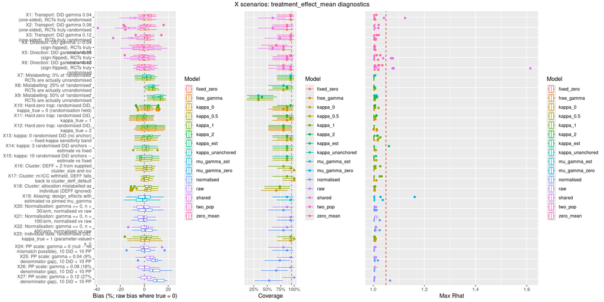

```r
plot_diagnostics(all_rep, all_agg, scenario_lookup_tbl, "X")
```

```r
results_table(all_agg, scenario_lookup_tbl, "X")
```

Category X: results

| Scenario | Description | Model | Fit | Parameter | Coverage | Bias | RMSE |
| --- | --- | --- | --- | --- | --- | --- | --- |
| X1 | Transport: DiD gamma 0.04 (one-sided), RCTs truly randomised | normalised; normal heterogeneity; pooled trend; imbalance by randomisation | fixed_zero | baseline_difference_sd | 0.933 | -0.004 | 0.024 |
|  |  |  | fixed_zero | time_trend_mean | 0.800 | 0.003 | 0.017 |
|  |  |  | fixed_zero | time_trend_sd | 0.800 | 0.003 | 0.021 |
|  |  |  | fixed_zero | treatment_effect_mean | 0.933 | 0.008 | 0.018 |
|  |  |  | fixed_zero | treatment_effect_sd | 0.867 | 0.005 | 0.015 |
|  |  |  | shared | baseline_difference_mean | 0.600 | -0.030 | 0.038 |
|  |  |  | shared | baseline_difference_sd | 1.000 | 0.000 | 0.015 |
|  |  |  | shared | time_trend_mean | 0.867 | 0.002 | 0.018 |
|  |  |  | shared | time_trend_sd | 0.733 | 0.004 | 0.020 |
|  |  |  | shared | treatment_effect_mean | 0.600 | -0.028 | 0.036 |
|  |  |  | shared | treatment_effect_sd | 0.933 | -0.001 | 0.018 |
|  |  |  | two_pop | baseline_difference_sd | 0.933 | -0.004 | 0.024 |
|  |  |  | two_pop | time_trend_mean | 0.800 | 0.004 | 0.018 |
|  |  |  | two_pop | time_trend_sd | 0.733 | 0.003 | 0.020 |
|  |  |  | two_pop | treatment_effect_mean | 0.933 | 0.008 | 0.017 |
|  |  |  | two_pop | treatment_effect_sd | 0.867 | 0.003 | 0.015 |
|  |  |  | zero_mean | baseline_difference_sd | 0.733 | -0.024 | 0.028 |
|  |  |  | zero_mean | time_trend_mean | 0.800 | 0.004 | 0.017 |
|  |  |  | zero_mean | time_trend_sd | 0.800 | 0.002 | 0.020 |
|  |  |  | zero_mean | treatment_effect_mean | 0.933 | 0.008 | 0.018 |
|  |  |  | zero_mean | treatment_effect_sd | 0.733 | -0.012 | 0.023 |
| X2 | Transport: DiD gamma 0.08 (one-sided), RCTs truly randomised |  | fixed_zero | baseline_difference_sd | 1.000 | 0.005 | 0.021 |
|  |  |  | fixed_zero | time_trend_mean | 0.933 | 0.001 | 0.014 |
|  |  |  | fixed_zero | time_trend_sd | 0.800 | 0.012 | 0.024 |
|  |  |  | fixed_zero | treatment_effect_mean | 0.867 | 0.000 | 0.020 |
|  |  |  | fixed_zero | treatment_effect_sd | 0.667 | 0.003 | 0.021 |
|  |  |  | shared | baseline_difference_mean | 0.067 | -0.086 | 0.090 |
|  |  |  | shared | baseline_difference_sd | 0.533 | 0.032 | 0.041 |
|  |  |  | shared | time_trend_mean | 0.933 | -0.001 | 0.016 |
|  |  |  | shared | time_trend_sd | 0.800 | 0.010 | 0.021 |

[output cut: 401 more lines]

## Convergence Diagnostics

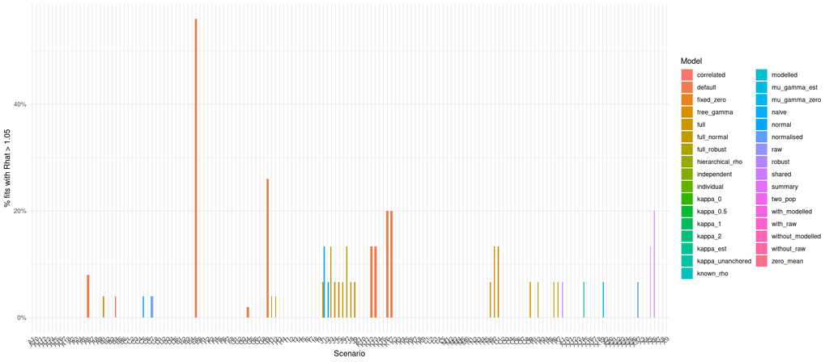

```r
plot_convergence(all_agg)
```

### Sampler divergences

The HMC sampler reports a divergent transition when its leapfrog integrator overshoots a sharp curve in the posterior. A few divergences in a long run are usually tolerable; many divergences flag a posterior geometry the sampler can’t navigate (typically funnels, hard constraints near the posterior bulk, or wide-uniform-prior pathologies).

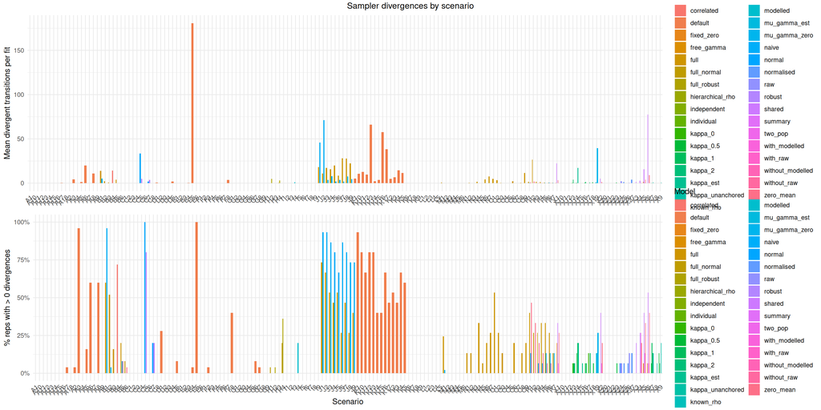

```r
plot_divergences(all_agg)
```

## Full Results Table

```r
all_agg |>
  arrange(scenario_id, model_label, parameter) |>
  kable(digits = 3, caption = "All aggregated results")
```

All aggregated results

| scenario_id | model_label | parameter | true_value | n_reps | empirical_coverage | mean_bias | median_bias | rmse | mean_ci_width | mean_posterior_sd | se_bias | se_ci_width | se_posterior_sd | max_rhat_worst | min_ess_worst | pct_rhat_bad | mean_n_divergent | max_n_divergent | pct_reps_with_divergence | pct_reps_many_divergence | mean_n_max_treedepth | min_ebfmi_worst |
| --- | --- | --- | --- | --- | --- | --- | --- | --- | --- | --- | --- | --- | --- | --- | --- | --- | --- | --- | --- | --- | --- | --- |
| A1 | default | baseline_difference_sd | 0.000 | 25 | 0.000 | 0.015 | 0.014 | 0.016 | 0.031 | 0.010 | 0.001 | 0.001 | 0.000 | 1.006 | 468.963 | 0.000 | 0.000 | 0 | 0.000 | 0.000 | 0.000 | 0.618 |
| A1 | default | time_trend_mean | -0.090 | 25 | 0.960 | -0.002 | -0.003 | 0.010 | 0.042 | 0.013 | 0.002 | 0.001 | 0.000 | 1.006 | 468.963 | 0.000 | 0.000 | 0 | 0.000 | 0.000 | 0.000 | 0.618 |
| A1 | default | time_trend_sd | 0.046 | 25 | 0.880 | 0.005 | 0.005 | 0.010 | 0.036 | 0.011 | 0.002 | 0.001 | 0.000 | 1.006 | 468.963 | 0.000 | 0.000 | 0 | 0.000 | 0.000 | 0.000 | 0.618 |
| A1 | default | treatment_effect_mean | -0.337 | 25 | 1.000 | -0.003 | 0.000 | 0.017 | 0.066 | 0.020 | 0.003 | 0.002 | 0.001 | 1.006 | 468.963 | 0.000 | 0.000 | 0 | 0.000 | 0.000 | 0.000 | 0.618 |
| A1 | default | treatment_effect_sd | 0.076 | 25 | 0.920 | 0.006 | 0.003 | 0.014 | 0.055 | 0.017 | 0.003 | 0.001 | 0.000 | 1.006 | 468.963 | 0.000 | 0.000 | 0 | 0.000 | 0.000 | 0.000 | 0.618 |
| A10 | default | baseline_control_mean | 0.450 | 25 | 1.000 | 0.001 | 0.001 | 0.010 | 0.041 | 0.013 | 0.002 | 0.001 | 0.000 | 1.034 | 142.828 | 0.000 | 0.000 | 0 | 0.000 | 0.000 | 0.000 | 0.646 |
| A10 | default | baseline_difference_sd | 0.000 | 25 | 0.000 | 0.022 | 0.020 | 0.024 | 0.045 | 0.014 | 0.001 | 0.002 | 0.001 | 1.034 | 142.828 | 0.000 | 0.000 | 0 | 0.000 | 0.000 | 0.000 | 0.646 |
| A10 | default | time_trend_mean | -0.040 | 25 | 0.880 | -0.001 | 0.000 | 0.007 | 0.021 | 0.007 | 0.001 | 0.001 | 0.000 | 1.034 | 142.828 | 0.000 | 0.000 | 0 | 0.000 | 0.000 | 0.000 | 0.646 |
| A10 | default | time_trend_sd | 0.020 | 25 | 0.840 | 0.000 | 0.000 | 0.007 | 0.020 | 0.006 | 0.001 | 0.001 | 0.000 | 1.034 | 142.828 | 0.000 | 0.000 | 0 | 0.000 | 0.000 | 0.000 | 0.646 |
| A10 | default | treatment_effect_mean | -0.150 | 25 | 0.840 | 0.000 | 0.000 | 0.006 | 0.023 | 0.007 | 0.001 | 0.001 | 0.000 | 1.034 | 142.828 | 0.000 | 0.000 | 0 | 0.000 | 0.000 | 0.000 | 0.646 |
| A10 | default | treatment_effect_sd | 0.030 | 25 | 0.840 | -0.001 | 0.001 | 0.007 | 0.020 | 0.006 | 0.001 | 0.000 | 0.000 | 1.034 | 142.828 | 0.000 | 0.000 | 0 | 0.000 | 0.000 | 0.000 | 0.646 |
| A11 | default | baseline_difference_sd | 0.000 | 15 | 0.000 | 0.024 | 0.024 | 0.025 | 0.030 | 0.009 | 0.002 | 0.001 | 0.000 | 1.012 | 522.472 | 0.000 | 0.000 | 0 | 0.000 | 0.000 | 0.000 | 0.747 |
| A11 | default | time_trend_mean | -0.090 | 15 | 0.867 | 0.001 | 0.001 | 0.010 | 0.038 | 0.012 | 0.003 | 0.002 | 0.000 | 1.012 | 522.472 | 0.000 | 0.000 | 0 | 0.000 | 0.000 | 0.000 | 0.747 |
| A11 | default | time_trend_sd | 0.046 | 15 | 0.933 | -0.001 | -0.002 | 0.009 | 0.033 | 0.010 | 0.002 | 0.001 | 0.000 | 1.012 | 522.472 | 0.000 | 0.000 | 0 | 0.000 | 0.000 | 0.000 | 0.747 |
| A11 | default | treatment_effect_mean | -0.337 | 15 | 0.933 | 0.007 | 0.007 | 0.017 | 0.064 | 0.020 | 0.004 | 0.004 | 0.001 | 1.012 | 522.472 | 0.000 | 0.000 | 0 | 0.000 | 0.000 | 0.000 | 0.747 |
| A11 | default | treatment_effect_sd | 0.076 | 15 | 0.733 | 0.002 | 0.005 | 0.021 | 0.053 | 0.016 | 0.006 | 0.003 | 0.001 | 1.012 | 522.472 | 0.000 | 0.000 | 0 | 0.000 | 0.000 | 0.000 | 0.747 |
| A12 | individual | baseline_difference_sd | 0.000 | 15 | 0.000 | 0.016 | 0.012 | 0.017 | 0.032 | 0.010 | 0.002 | 0.002 | 0.001 | 1.005 | 337.814 | 0.000 | 0.000 | 0 | 0.000 | 0.000 | 0.000 | 0.604 |
| A12 | individual | time_trend_mean | -0.090 | 15 | 0.733 | 0.000 | -0.001 | 0.012 | 0.036 | 0.011 | 0.003 | 0.002 | 0.000 | 1.005 | 337.814 | 0.000 | 0.000 | 0 | 0.000 | 0.000 | 0.000 | 0.604 |
| A12 | individual | time_trend_sd | 0.046 | 15 | 0.867 | -0.004 | -0.006 | 0.010 | 0.032 | 0.010 | 0.003 | 0.001 | 0.000 | 1.005 | 337.814 | 0.000 | 0.000 | 0 | 0.000 | 0.000 | 0.000 | 0.604 |
| A12 | individual | treatment_effect_mean | -0.337 | 15 | 0.733 | 0.004 | 0.003 | 0.025 | 0.062 | 0.019 | 0.007 | 0.003 | 0.001 | 1.005 | 337.814 | 0.000 | 0.000 | 0 | 0.000 | 0.000 | 0.000 | 0.604 |
| A12 | individual | treatment_effect_sd | 0.076 | 15 | 0.933 | -0.001 | 0.000 | 0.015 | 0.052 | 0.016 | 0.004 | 0.002 | 0.001 | 1.005 | 337.814 | 0.000 | 0.000 | 0 | 0.000 | 0.000 | 0.000 | 0.604 |
| A12 | summary | baseline_difference_sd | 0.000 | 15 | 0.000 | 0.016 | 0.012 | 0.017 | 0.032 | 0.010 | 0.002 | 0.002 | 0.001 | 1.007 | 494.936 | 0.000 | 0.000 | 0 | 0.000 | 0.000 | 0.000 | 0.679 |
| A12 | summary | time_trend_mean | -0.090 | 15 | 0.800 | 0.000 | -0.001 | 0.012 | 0.036 | 0.011 | 0.003 | 0.002 | 0.000 | 1.007 | 494.936 | 0.000 | 0.000 | 0 | 0.000 | 0.000 | 0.000 | 0.679 |
| A12 | summary | time_trend_sd | 0.046 | 15 | 0.867 | -0.004 | -0.006 | 0.010 | 0.032 | 0.010 | 0.003 | 0.001 | 0.000 | 1.007 | 494.936 | 0.000 | 0.000 | 0 | 0.000 | 0.000 | 0.000 | 0.679 |
| A12 | summary | treatment_effect_mean | -0.337 | 15 | 0.733 | 0.004 | 0.004 | 0.026 | 0.062 | 0.019 | 0.007 | 0.003 | 0.001 | 1.007 | 494.936 | 0.000 | 0.000 | 0 | 0.000 | 0.000 | 0.000 | 0.679 |
| A12 | summary | treatment_effect_sd | 0.076 | 15 | 0.933 | -0.001 | 0.000 | 0.015 | 0.051 | 0.016 | 0.004 | 0.002 | 0.001 | 1.007 | 494.936 | 0.000 | 0.000 | 0 | 0.000 | 0.000 | 0.000 | 0.679 |
| A13 | hierarchical_rho | baseline_difference_sd | 0.000 | 25 | 0.000 | 0.016 | 0.016 | 0.017 | 0.031 | 0.010 | 0.001 | 0.001 | 0.000 | 1.008 | 358.832 | 0.000 | 0.000 | 0 | 0.000 | 0.000 | 0.000 | 0.612 |
| A13 | hierarchical_rho | time_trend_mean | -0.090 | 25 | 0.800 | -0.006 | -0.004 | 0.014 | 0.039 | 0.012 | 0.003 | 0.001 | 0.000 | 1.008 | 358.832 | 0.000 | 0.000 | 0 | 0.000 | 0.000 | 0.000 | 0.612 |
| A13 | hierarchical_rho | time_trend_sd | 0.046 | 25 | 0.880 | 0.000 | -0.001 | 0.010 | 0.034 | 0.011 | 0.002 | 0.001 | 0.000 | 1.008 | 358.832 | 0.000 | 0.000 | 0 | 0.000 | 0.000 | 0.000 | 0.612 |
| A13 | hierarchical_rho | treatment_effect_mean | -0.337 | 25 | 0.920 | 0.010 | 0.012 | 0.018 | 0.070 | 0.021 | 0.003 | 0.003 | 0.001 | 1.008 | 358.832 | 0.000 | 0.000 | 0 | 0.000 | 0.000 | 0.000 | 0.612 |

[output cut: 1527 more lines]